# Analyzing Football tweets at the University of Florida

Cheryl Calhoun

11/22/2015

The goal of this project is to collect tweets from each football game during the regular season and then see if we can develop a model that will help us to predict whether or not the team will win or lose, win or loose by 7, or beat the spread.

# Setting up the Work Environment

For this project we will use a number of R packages. Included below is the code block for installing and including these packages for use. Some of the lines are commented out because they don’t need to run with each execution, but will need to be run in the first execution if not already installed.

```r
## Setting the working directory path so that all the files will load correctly.

## setwd("C:/Users/Cheryl/OneDrive/Education/UF/2015/Fall/EDF6938/Calhoun-Final/FinalProject")    ## Work computer
## setwd("C:/Users/Cheryl/OneDrive/Education/UF/2015/Fall/EDF6938/Calhoun-Final/FinalProject")     ## Home computer

## Install `twitterR` and supporting packages if not already installed.
## download.file(url="http://curl.haxx.se/ca/cacert.pem", destfile="cacert.pem") ##-- this was suggested if you are running a Windows machine.
## install.packages("dplyr", "twitteR", "RCurl", "RJSONIO", "stringr", "base64enc", "wordcloud", "tm", "knitr")

## Loading twitterR and other supporting libraries.
library(dplyr)               # Data preparation and pipes %>%
library(twitteR)             # Provides an interface to the Twitter Web API
library(RCurl)               # The RCurl package is an R-interface to the libcurl library that provides HTTP facilities.
library(wordcloud)           # Allows us to create a word cloud.
library(tm)                  # A framework for text mining applications within R.
library(RJSONIO)             # This provides compatiblity between R, Javascript & JSON.
library(stringr)             # Provides additional functions for manipulating strings.
library(base64enc)           # Provides tools for base64 encoding.
library(knitr)               # Gives access to more sophisticated printing options.
library(ggplot2)             # Gives additonal graphing options


## Loading twitter API and Access keys. Use this when extracting data using `twitterR`.
## source ("../OriginalData/twitter-access-keys.R")
## setup_twitter_oauth(consumer_key, consumer_secret, access_token, access_secret)

## Need to install Rtools before loading `devtools`, or you will get the following error.
## WARNING: Rtools is required to build R packages, but is not currently installed.
## Please download and install Rtools 3.3 from http://cran.r-project.org/bin/windows/Rtools/ and then run find_rtools().

## Setting up for sentiment analysis. Install packages if necessary.
## First, install an alternate repository.
## install.packages("Rstem", repos = "http://www.omegahat.org/R", type="source")
library(Rstem)
library(sentiment)

## Second, we can use packages hosted on GitHub.  Install packages if necessary.
## install.packages("devtools")
## install_github ("timjurka/sentiment/sentiment")
library(devtools)

## Loading variables.

## Setting search patterns for usertags and hashtags.
usertag <- "@[A-z_0-9]+"
hashtag <- "#[A-z0-9]+"
dates <- c("Oct 13", "Sep 01", "Nov 09", "Nov 13", "Dec 12")

## Load the subjectivity and emotions files from (https://github.com/timjurka/sentiment/tree/master/sentiment)
## subjectivity <- read.csv ("http://www.acthomas.ca/FSSS/data/subjectivity.csv", header=FALSE)
## emotions <- read.csv ("http://www.acthomas.ca/FSSS/data/emotions.csv", header=FALSE)
```

Back to Top

# Gathering the Data

## Data Storage Structure

Data will be captured from the twitter API for each game, saved to a file, and reloaded from that file as needed. This will ensure both reproducibility and ease of use on Twitter’s servers. A folder named “OriginalData” was created to hold original source files. A second folder named “FinalProject” was created to hold the contents of the project as it is created and analyzed. These both exist within the Calhoun-Final.

- Calhoun-Final
- Original Data
- FinalProject

## Data Collection

The original plan was to use `twitterR` with geolocation to find our tweets. To do this, we need to find the latitude and longitude of our school on Google Maps. (This is a manual process of looking up the coordinates.) The latitude and longitude of Ben Hill Griffin stadium at the University of Florida is: 29.649898, -82.348429. Now, we can use these coordinates to extract a sample of tweets from near that location. For this exercise, we will use a 5 mile radius.

**Results:** Unfortunately, geolocation does not seem to work, so for plan B we will use the most common hashtag associated with Florida Sports and Florida Football. After some initial data exploration, the #GoGators hashtag is selected.

**11/14/15 Update - Game 9:** After review of tweets obtained using the #GoGators hashtag, it is apparent that this data set includes tweets from all Gator sports as well as many other miscellaneous tweets. Further research through twitter, and confirmed by watching the game, indicates there is a game specific hashtag each week. The game specific hashtag for Game 10 is #UFvsSC. I will use the game specific hashtag to gather the tweets for each game remaining in the season. I will also search for tweets on the flipped hashtag, ex. #SCvsUF as this seems to be a common inversion of the official game hashtag. Tweets will be collected for the entire week prior to game day, starting on the Saturday before the game and ending on the Friday before the game.

**11/23/15 Update - Previous Games:** In order to have a complete season worth of data to develop our model, we will need to develop a method of capturing data prior to Game9. Unfortunately the twitter API only returns tweets from the previous two weeks, so we will need to develop a method to capture twitter traffic from Game1 - Game8 which occurred prior to beginning this project. I’ve detailed this process in the *Data Collection* section below.

Back to Top

## Schedule Results

Game Results and Spread Data Table

| Game | GAMEDATE | OPPONENT | H.A | RESULT | UFSCORE | OSCORE | MARGIN | SPREAD | COVER | BEAT | HASHTAG |
| --- | --- | --- | --- | --- | --- | --- | --- | --- | --- | --- | --- |
| Game01 | 2015-09-05 | New Mexico State | H | W | 61 | 13 | 48 | -34.0 | 14.0 | yes | NMSUvsUF |
| Game02 | 2015-09-12 | East Carolina | H | W | 31 | 24 | 7 | -20.5 | -13.5 | no | ECUvsUF |
| Game03 | 2015-09-19 | Kentucky | A | W | 14 | 9 | 5 | -3.5 | 1.5 | yes | UFvsUK |
| Game04 | 2015-09-26 | Tennessee | H | W | 28 | 27 | 1 | 1.0 | 2.0 | yes | TENNvsUF |
| Game05 | 2015-10-03 | Ole Miss | H | W | 38 | 10 | 28 | 6.5 | 34.5 | yes | MISSvsUF |
| Game06 | 2015-10-10 | Missouri | A | W | 21 | 3 | 18 | 11.5 | 29.5 | yes | UFvsMIZZ |
| Game07 | 2015-10-17 | LSU | A | L | 28 | 35 | -7 | 6.0 | -1.0 | no | UFvsLSU |
| Game08 | 2015-10-31 | Georgia | A | W | 27 | 3 | 24 | -1.5 | 22.5 | yes | UFvsUGA |
| Game09 | 2015-11-07 | Vanderbilt | H | W | 9 | 7 | 2 | -21.0 | -19.0 | no | VANDYvsUF |
| Game10 | 2015-11-14 | South Carolina | A | W | 24 | 14 | 10 | -7.0 | 3.0 | yes | UFvsSC |
| Game11 | 2015-11-21 | Florida Atlantic | H | W | 20 | 14 | 6 | -28.5 | -22.5 | no | FAUvsUF |
| Game12 | 2015-11-28 | Florida State | H | L | 2 | 27 | -25 | 2.5 | -22.5 | no | FSUvsUF |

**Note:** This table was created using the `kable` function, from the stored Schedule.csv file in a non-displayed (echo=FALSE) r chunk. The results and spread data were collected using COVERS (http://www.covers.com/sports/ncaaf). This data was entered into an Excel spreadsheet and exported to Schedule.csv.

Back to Top

## Data Collection

This project will use a two step data collection process. For games before week 9, we will use a copy and paste process. For games beginning in week 9, we will use the twitter API.

### Game 01 through Game 08

For these games data was collected using a copy and paste method from the [Twitter](https://twitter.com) website. This manual method was required due to the retroactive nature of this project. Since the twitter API will only reach back 2 weeks, this allows us to pull data from previous games. In order to have a true analysis, we would need to gather data using the twitter API beginning with the first game and build throughout the season.

**Copy and Paste Process:**

1. An advanced search was created using Twitter’s advanced search page (https://twitter.com/search-advanced). Search terms included the game specific hashtag and its inverse, (Ex. #UFvsSC and #SCvsUF) and the date range encompassing the week prior to game day (Sunday - Friday)
2. Since this page only shows a small number of tweets, it was required to scroll down through the tweets until twitter revealed the maximum number of tweets. (I suspect this is still not all of them, as the numbers obtained using this method are substantially smaller than those obtained using the `twitterR` function in Games 10-12.)
3. The center column containing tweets was copied and pasted into Notepad+.
4. The file was then saved as a .txt file using the hashcode as the filename.
5. The data was then imported into R and manipulated into a dataframe as demonstrated in the `Game 1` R code chunk.

```r
## Collect data for Game 1 using the #MNSUvsUF and #UFvsMNSU hashtags.
copiedPage <- paste (readLines("../OriginalData/NMSUvsUF.txt"), collapse = " ")

## Extract just the tweet data from the file.
Game1 <- regmatches(copiedPage, gregexpr ('[@].*?(?=[0-9]* retweet)', copiedPage, perl=TRUE))
Game1 <- unlist(Game1)
Game1 <- as.data.frame(Game1)

## Save original data frame before beginning column manipulation.
write.csv(Game1, file = "Game1.csv")

## Create a column containing the game identifier.
Game1 <- mutate (Game1, Game="Game01")

## Create a column containing the screenName.
Game1 <- mutate (Game1, screenName=regmatches(Game1$Game1, gregexpr("^.*?(?= )", Game1$Game1,  perl=TRUE)))
Game1$screenName <- gsub("@", "", Game1$screenName)

## Filter out official twitter account tweets based on screenName.
Game1 <- filter(Game1, screenName!="FloridaGators")
Game1 <- filter(Game1, screenName!="GatorsFB")
Game1 <- filter(Game1, screenName!="UF")

## Create a column for the date of the tweet.
Game1 <- mutate (Game1, date=regmatches(Game1$Game1, gregexpr("([JFMASOND][a-z]{2} [0-9]{1,2})", Game1$Game1,  perl=TRUE)))
Game1 <- mutate (Game1, text=regmatches(Game1$Game1, gregexpr("(?<=[JFMASOND][a-z]{2} [0-9]).*", Game1$Game1,  perl=TRUE)))

## Create a column for the content of the tweet text.
Game1$text <- gsub("[0-9] ", "", Game1$text)

## Format date.
Game1$date <- gsub("Sep 4", "2015-09-04", Game1$date)
Game1$date <- gsub("Sep 3", "2015-09-03", Game1$date)
Game1$date <- gsub("Sep 2", "2015-09-02", Game1$date)
Game1$date <- gsub("Sep 1", "2015-09-01", Game1$date)
Game1$date <- gsub("Aug 31", "2015-08-31", Game1$date)
Game1$date <- gsub("Aug 30", "2015-08-30", Game1$date)
Game1$date <- as.Date (Game1$date)

## Select columns we will use in our analysis.
Game1 <- select(Game1, Game, screenName, date, text)

## Save completed data frame.
save (Game1, file="Game1.RData")

## Display the format of the game data frame for Games 1 - 8.
kable(Game1[1,], digits=2, caption="Example row in the Game1 data frame.")
```

**Note:** The same method was used for developing the data frames for Games2-8. I’ve hidden the R code chunks using `echo=FALSE` in order to conserve on space in the final report.

Back to Top

### Game 09 through Game 12

For Games 9 through 12 we are able to collect data using the `twitterR` function which accesses the twitter API. Tweets are selected using the game specific hashtag and date range. It is then put into a dataframe using `rbind_all()` and `lapply`. The following code chunk illustrates how the Game 09 data was manipulated to create a final data frame for analysis.

```r
## The original geolocation code which was determined not to be effective for this project.
## Florida <- searchTwitter('', geocode='29.649898,-82.348429,5mi', since="2015-11-05", until="2015-11-09", n=10000)

## Collect weekly tweets beginning Thursday before game and ending on Sunday after the game. Store tweets in a .csv file.  This code will be executed on a weekly basis until we have gathered data for the remaining 4 games of the season.

##Collect data for Game 9 using the updated #GoGators hashtag code.
##Florida9 <- searchTwitter("#GoGators", since="2015-11-05", until="2015-11-07", n=10000, retryOnRateLimit=120)
##Florida9.df <- rbind_all (lapply (Florida9, function(rr) rr$toDataFrame()))

## Save original data file for later processing.
##write.csv(Florida9.df, file = "Game9.csv")
Game9 <- read.csv("../OriginalData/Game9.csv")

## Create a column containing the game identifier.
Game9 <- mutate (Game9, Game="Game09")

## Remove tweets from FloridaGators, GatorsFB and UF.
Game9 <- filter(Game9, screenName!="FloridaGators")
Game9 <- filter(Game9, screenName!="GatorsFB")
Game9 <- filter(Game9, screenName!="UF")

## Reduce the tweets to only those that mention hashtag #VANDYvsUF.  This will remove non-game related tweets and align this data set with the same criteria used to collect all the other game data sets.
Game9 <- Game9[grep("VANDYvsUF", Game9$text), ]

## Remove retweets. This will prevent duplicates.
Game9 <- Game9[grep("RT @", Game9$text, invert=TRUE), ]

## Select columns we will use in our analysis.
Game9 <- select(Game9, Game, screenName, date=created, text)
Game9$date <- as.Date (Game9$date)
Game9$text <- as.character(Game9$text)

## Save completed data frame.
save (Game9, file="Game9.RData")

## Display the format of the game data frame for Games 9 - 12.
kable(Game9[10,], caption="Example row in the Game9 data frame.")
```

**Note:** The same method was used for developing the data frames for Games 10-11. I’ve hidden the R code chunks using `echo=FALSE` in order to conserve on space in the final report.

### Loading the Data Sets for Analysis

All data from the above Game code blocks was saved to `all.RData` for future analysis. This code block will load the data set so that we can begin analysis.

```r
## Creating a `Vanderbilt` data frame to hold the tweets from Game9.  This will allow us to experiment with analysis without affecting the main dataframe.  This only needs to be run once after data sets have been created.  It will be saved within the all.RData set below.
Vanderbilt <- Game9

## Combine all game tweets into one big file.
GameTweets <- bind_rows(Game1, Game2, Game3, Game4, Game5, Game6, Game7, Game8, Game9, Game10, Game11, Game12)

## This code block is designed to initially save, and then load all data for analysis.
## Saving the whole data set.
save(list = ls(all = TRUE), file= "all.RData")
```

```r
## Load the final data set for analysis.
load("all.RData")
```

Back to Top

# Trial Analysis

## Homework #8 Testing Hashtag & User Analysis

### Evaluating HashTags for Game 9: Vanderbilt

Determining the number of hashtags used in each tweet and overall in the sample.

```r
## Find hashtags for Game 9. Create dataframe `Vanderbilt` by adding a column for hashtags and a column for number of hashtags.
Vanderbilt <- mutate (Vanderbilt, hashtags=regmatches(Vanderbilt$text, gregexpr(hashtag, Vanderbilt$text)))
Vanderbilt <- mutate (Vanderbilt, HQty=as.integer(lapply(Vanderbilt$hashtags, function(x) length(x))))
```

Determining the number of tweets at each hashtag level.

```r
## Create a Hashtags per Tweet table.
HashtagsperTweet = table(Vanderbilt$HQty)
HashtagsperTweetTable = as.data.frame(HashtagsperTweet)
names(HashtagsperTweetTable)[1] = 'Number of Hashtags'
names(HashtagsperTweetTable)[2] = 'Number of Tweets'
HashtagsperTweetTable
```

```
##   Number of Hashtags Number of Tweets
## 1                  2              140
## 2                  3               76
## 3                  4               54
## 4                  5               24
## 5                  6               12
## 6                  7                3
## 7                  8                3
```

Determining the number of hashtags in the data set.

```r
## Determine total number of hashtags.
all.hashtags <- unlist(regmatches(Vanderbilt$text, gregexpr (hashtag, Vanderbilt$text)))

## Determine total number of unique hashtags.
unique.hashtags <- unique(all.hashtags <- unlist(regmatches(Vanderbilt$text, gregexpr (hashtag, Vanderbilt$text))))
## all.hashtags
```

Using the `length()` function, there are a total of 961 hashtags in the data set.

Using the `length()` function, there are 125 unique hashtags in the data set.

Finding the most frequently used hashtags.

```r
## Count the hashtag usage.
hashtags.df <- data.frame(cbind(all.hashtags))
hashcount <- count(hashtags.df, all.hashtags)
hashcount <- hashcount[order(-hashcount$n),]
hashcount
```

```
## Source: local data frame [125 x 2]
##
##        all.hashtags   n
## 1        #VANDYvsUF 312
## 2         #GoGators 285
## 3           #Gators  44
## 4      #GatorNation  24
## 5  #SportsRoadhouse  24
## 6        #BeatVandy  19
## 7     #UFHomecoming  16
## 8         #gogators  15
## 9       #ItsGreatUF  14
## 10        #GOGATORS  12
## ..              ... ...
```

Back to Top

### Evaluating UserTags for Game 9: Vanderbilt

Determining the number of users tagged in each tweet.

```r
## Find users for Vanderbilt. Add a column for usertags and a column for number of user tags in the tweet.
Vanderbilt <- mutate (Vanderbilt, usertags=regmatches(Vanderbilt$text, gregexpr(usertag, Vanderbilt$text)))
Vanderbilt <- mutate (Vanderbilt, UQty=as.integer(lapply(Vanderbilt$usertags, function(x) length(x))))
```

The number of users tagged per tweet.

```r
## Create a UserTags per Tweet table.
UserTagsperTweet = table(Vanderbilt$UQty)
UserTagsperTweetTable = as.data.frame(UserTagsperTweet)
names(UserTagsperTweetTable)[1] = 'Number of Users'
names(UserTagsperTweetTable)[2] = 'Number of Tweets'
UserTagsperTweetTable
```

```
##   Number of Users Number of Tweets
## 1               0              224
## 2               1               62
## 3               2               21
## 4               3                5
```

The total number of usertags in the data set.

```r
## Determine total number of usertags
all.usertags <- unlist(regmatches(Vanderbilt$text, gregexpr (usertag, Vanderbilt$text)))
length(all.usertags)
```

```
## [1] 119
```

The total number of unique usertags in the data set.

```r
## Determine total number of unique usertags
unique.usertags <- unique(all.usertags <- unlist(regmatches(Vanderbilt$text, gregexpr (usertag, Vanderbilt$text))))
length(unique.usertags)
```

```
## [1] 45
```

Finding the most commonly used usertags.

```r
## Count the usertag usage.
usertags.df <- data.frame(cbind(all.usertags))
usercount <- count(usertags.df, all.usertags)
usercount <- usercount[order(-usercount$n),]
usercount
```

```
## Source: local data frame [45 x 2]
##
##        all.usertags  n
## 1         @GatorsFB 42
## 2    @FloridaGators 17
## 3               @UF  7
## 4    @CoachMcElwain  5
## 5              @SEC  3
## 6  @Austin_Hardin16  2
## 7       @bethmowins  2
## 8   @Kelvintaylor21  2
## 9         @ufalumni  2
## 10   @VandyFootball  2
## ..              ... ..
```

Back to Top

### Finding the top 25 most frequent tweeters.

The following 25 users tweeted most frequently during each game period. The usertags were selected after eliminating users that were clearly accounts for the team proper or their PR department. That is, we’re trying to find a fan community for your team that tweets about their team’s games on a regular basis. This community will form the basis for the project looking ahead.

```r
## Find the 25 users that tweeted most frequently during Game 9 & 10.
frequenttweeters <- summarise(group_by(GameTweets, screenName), count=n())
frequenttweeters <- frequenttweeters[order(-frequenttweeters$count),]
frequenttweeters$screenName[1:25]
```

```
##  [1] "_Whoa_itsPayge_" "gator_fbreport"  "JayrockJenkins"
##  [4] "TampaBaySRH"     "PancholoJimenez" "GatorsSRH"
##  [7] "LFTorresIII"     "GatorVisionTV"   "gatorlane"
## [10] "TylerWardFilms"  "Emmy_ArmadaFC"   "BrookinsOneil"
## [13] "GatorsScott"     "bmanning96"      "ESPNGainesville"
## [16] "FLvsGA"          "ChaseRojas"      "cdcoldplay1"
## [19] "Jayspifflife"    "AllThingsUF"     "SportsUSAMedia"
## [22] "OHareTyler22"    "dassadi_lmco"    "SWNY315"
## [25] "ShaneBrowns"
```

The top 25 individual tweeters for Game1 through Game12 are: *Whoa_itsPayge*, gator_fbreport, JayrockJenkins, TampaBaySRH, PancholoJimenez, GatorsSRH, LFTorresIII, GatorVisionTV, gatorlane, TylerWardFilms, Emmy_ArmadaFC, BrookinsOneil, GatorsScott, bmanning96, ESPNGainesville, FLvsGA, ChaseRojas, cdcoldplay1, Jayspifflife, AllThingsUF, SportsUSAMedia, OHareTyler22, dassadi_lmco, SWNY315, ShaneBrowns

Back to Top

## Homework #9 Testing Sentiment Analysis

### Looking at user opinions

Now that we have our top 25 users we want to look at their opinions about their team’s upcoming performance in the next football game. For now we’ll manipulate the data using the sentiment analysis tools we just acquired, and inspecting the capabilities of the R package `sentiment` to judge its usefulness

#### Analyzing a small sample of 10 tweets from Game 9.

```r
TenTweets <- slice(Vanderbilt, 1)
TenTweets <- bind_rows(TenTweets, slice(Vanderbilt, 10))
TenTweets <- bind_rows(TenTweets, slice(Vanderbilt, 20))
TenTweets <- bind_rows(TenTweets, slice(Vanderbilt, 30))
TenTweets <- bind_rows(TenTweets, slice(Vanderbilt, 40))
TenTweets <- bind_rows(TenTweets, slice(Vanderbilt, 50))
TenTweets <- bind_rows(TenTweets, slice(Vanderbilt, 60))
TenTweets <- bind_rows(TenTweets, slice(Vanderbilt, 70))
TenTweets <- bind_rows(TenTweets, slice(Vanderbilt, 80))
TenTweets <- bind_rows(TenTweets, slice(Vanderbilt, 90))
TenTweets$text
```

```
##  [1] "At least we are SEC East champions. We clinched it on an ugly win. <ed> ½<ed>° #GoGators #VANDYvsUF"
##  [2] "It's 4:56PM EST, and I just got called for targeting. #SECchamps #gogators #VANDYvsUF"
##  [3] "@GatorsFB @UF Georgia on my mind! #VANDYvsUF #GoGators https://t.co/YXXW1zcZmq"
##  [4] "What a CRAZY GAME but we got that WIN!!!! #VANDYvsUF #GatorNation #GoGators <ed> ½<ed>°<ed> ½<ed>°<ed> ½<ed>°<ed> ½<ed>°"
##  [5] "#VANDYvsUF Florida wins 9-7 despite four turnovers #gogators"
##  [6] "Downright ugly, but to be in a the SEC title game in @CoachMcElwain 's 1st year is more than the #Gators can ask 4.  #VANDYvsUF #GoGators"
##  [7] "Rough game #VANDYvsUF but here's a smile for all my fellows #Gators https://t.co/GjZ3BJsIhA #GoGators #GatorFilmMakers #SECNation #airbnb"
##  [8] "Florida survives, 9-7, and clinches the SEC East. #VANDYvsUF #GoGators"
##  [9] "That wasn't pretty, but playing in the SEC never is! #GoGators #GatorsDefense #VANDYvsUF #SECChampionship"
## [10] "Big sack baby big sack #VANDYvsUF #GoGators #GatorNation stand up!! Best defense in the country"
```

#### Let’s see what the classifiers have to offer.

We’ll run the classifiers on the `TenTweets` extraction of text, using `verbose=TRUE` so we can see how each word is being scored by the classifier.

```r
polarity.df <- as.data.frame(classify_polarity(TenTweets$text))
TenTweets <- cbind(TenTweets, polarity.df$BEST_FIT)
polarity <- classify_polarity (TenTweets$text, verbose = TRUE)
```

```
## [1] "DOCUMENT 1"
## [1] "WORD: least CAT: negative POL: weaksubj SCORE: 8.33686963728496"
## [1] "WORD: ugly CAT: negative POL: strongsubj SCORE: 9.0300168178449"
## [1] "POS: 1.03127774142571 NEG: 17.8123396772424 RATIO: 0.0578968153601572"
##
## [1] "DOCUMENT 2"
## [1] "WORD: just CAT: positive POL: strongsubj SCORE: 8.44419229853175"
## [1] "POS: 9.47547003995745 NEG: 0.445453222112551 RATIO: 21.2715265477714"
##
## [1] "DOCUMENT 3"
## [1] "WORD: mind CAT: negative POL: weaksubj SCORE: 8.33686963728496"
## [1] "POS: 1.03127774142571 NEG: 8.78232285939751 RATIO: 0.117426534862834"
##
## [1] "DOCUMENT 4"
## [1] "WORD: crazy CAT: negative POL: strongsubj SCORE: 9.0300168178449"
```

[output cut: 32 more lines]

```r
emotion <- classify_emotion (TenTweets$text, verbose = TRUE)
```

```
## [1] "DOCUMENT 1"
## [1] "WORD: ugly CAT: fear SCORE: 5.27299955856375"
## [1] "DOCUMENT 2"
## [1] "WORD: est CAT: joy SCORE: 6.31535800152233"
## [1] "DOCUMENT 3"
## [1] "DOCUMENT 4"
## [1] "DOCUMENT 5"
## [1] "WORD: despite CAT: anger SCORE: 5.87211778947542"
## [1] "DOCUMENT 6"
## [1] "WORD: ugly CAT: fear SCORE: 5.27299955856375"
## [1] "DOCUMENT 7"
## [1] "DOCUMENT 8"
## [1] "DOCUMENT 9"
## [1] "DOCUMENT 10"
```

**Results:** In evaluating the question, “Are there any definitions of polarity that surprise you given their context?”, I have to say, I can’t really see where the positive, neutral, and negative polarities are highly correlated to how I would view these tweets." I suspect, that sports analogies may be difficult to rate because the sentiments are sometimes inverse to how they might be evaluated. For example, how is “not pretty” evaluated?

For example, in looking at the results from the polarity analysis of the ten tweets, you can see that some words are used in an inverse fashion when describing sports. Tweet #6 gets a strong negative rating. In reading the tweet, it could be considered negative, but it is also somewhat positive. The conflicting terms are “Downright ugly”, and then a reference to the concept that the Gators are performing better than can be expected in Coach McElwains first year.

Back to Top

### Now let’s look at the full data set.

We’ll run the classifiers on the full data set for Game 9, then add the classifiers (and only the classifiers, not the raw scores) as columns to the existing Game 9 data frame. Next, we’ll look for the number of tweets that are classified “positive” subjectivity as well as the number classified as “joy” emotions?

#### Positive vs Negative

```r
## Create a dataframe to hold the polarity classifiers. Save this dataframe so it can be reloaded in later iterations.  This will save time in processing.
polarity9.df <- as.data.frame(classify_polarity(Vanderbilt$text))
polarity9.df <- rename(polarity9.df, PBEST_FIT = BEST_FIT)

## Bind the polarity classifier back to the original Vanderbilt data set.
Vanderbilt <- cbind(Vanderbilt, PBEST_FIT = polarity9.df$PBEST_FIT)
BestFitTable <- Vanderbilt %>% count(PBEST_FIT)
```

**Results:** Using the `count` function, the number of tweets that can be classified as “positive” are: 202.

#### Expressions of Emotion

```r
## Create a dataframe to hold the emotion classifiers. Save this dataframe so it can be reloaded in later iterations.  This will save time in processing.
emotion9.df <- as.data.frame(classify_emotion(Vanderbilt$text))
emotion9.df <- rename(emotion9.df, EBEST_FIT = BEST_FIT)

## Bind the emotion classifiers back to the original GameTweets data set
Vanderbilt <- cbind(Vanderbilt, emotion9.df)
BestFitTable <- Vanderbilt %>% count(EBEST_FIT)
```

**Results:** Using the `count` function, the number of tweets that can be classified as “joy” are: 67.

#### Fraction of Positive Tweets

Now we will use `group_by` and `summarize` to find the fraction of tweets that are positive, neutral and negative for each user-day combination.

```r
## Create a new dataframe `polarity.df` to hold the summary table.
polarity.df <- Vanderbilt %>%
  group_by(screenName, date) %>%
  summarise(Positive = sum(PBEST_FIT=="positive"),
            Neutral = sum(PBEST_FIT=="neutral"),
            Negative = sum(PBEST_FIT=="negative"),
            Total = n(),
            PosFrac = sum(PBEST_FIT=="positive")/n(),
            NeutFrac = sum(PBEST_FIT=="neutral")/n(),
            NegFrac = sum(PBEST_FIT=="negative")/n())

## Sort the dataframe by total so that output will display the most active tweeters at the top.
polarity.df <- polarity.df[order(-polarity.df$Total),]
kable(polarity.df[1:10,], digits=2, caption="Top Ten Positive Tweeters by Day")
```

Top Ten Positive Tweeters by Day

| screenName | date | Positive | Neutral | Negative | Total | PosFrac | NeutFrac | NegFrac |
| --- | --- | --- | --- | --- | --- | --- | --- | --- |
| gogators1974 | 2015-11-07 | 13 | 0 | 5 | 18 | 0.72 | 0.00 | 0.28 |
| GatorsSRH | 2015-11-07 | 11 | 0 | 1 | 12 | 0.92 | 0.00 | 0.08 |
| TampaBaySRH | 2015-11-07 | 11 | 0 | 1 | 12 | 0.92 | 0.00 | 0.08 |
| Kilrah01 | 2015-11-07 | 6 | 1 | 3 | 10 | 0.60 | 0.10 | 0.30 |
| jdonaldsonCSN | 2015-11-07 | 4 | 1 | 2 | 7 | 0.57 | 0.14 | 0.29 |
| mikecombs386 | 2015-11-07 | 4 | 1 | 2 | 7 | 0.57 | 0.14 | 0.29 |
| Lngillespie23 | 2015-11-07 | 5 | 0 | 1 | 6 | 0.83 | 0.00 | 0.17 |
| TOTODUVALDIVA | 2015-11-07 | 5 | 0 | 0 | 5 | 1.00 | 0.00 | 0.00 |
| EBEARJR | 2015-11-07 | 4 | 0 | 0 | 4 | 1.00 | 0.00 | 0.00 |
| golfer380 | 2015-11-07 | 3 | 1 | 0 | 4 | 0.75 | 0.25 | 0.00 |

#### Fraction of Tweets that Show Joy or Sadness

Now let’s find which users have the greatest propensity for “joy”? Which for “sadness”? These tables give an indication of the strength of emotion for each of the top ten tweeters. Unfortunately this data set did not have enough data from multiple days to do a day by day comparison. I will attempt to work this into my overall analysis.

```r
## Create a new dataframe `emotion.df` to hold the summary table.
emotion.df <- Vanderbilt %>%
  group_by(screenName, date) %>%
  summarise(ANGER = sum(ANGER)/n(),
            DISGUST = sum(DISGUST)/n(),
            FEAR = sum(FEAR)/n(),
            JOY = sum(JOY)/n(),
            SADNESS = sum(SADNESS)/n(),
            SURPRISE = sum(SURPRISE)/n())

## Sort the dataframe by total so that output will display the most active tweeters at the top.
emotion.df <- emotion.df[order(-emotion.df$JOY),]
mostjoy <- emotion.df$screenName[1]
kable(emotion.df[1:10, ], caption="Top Ten Tweeters by Day for Expressing Joy")
```

Top Ten Tweeters by Day for Expressing Joy

| screenName | date | ANGER | DISGUST | FEAR | JOY | SADNESS | SURPRISE |
| --- | --- | --- | --- | --- | --- | --- | --- |
| AmberBloom8 | 2015-11-07 | 1 | 1 | 1 | 3 | 1 | 2 |
| annieonline | 2015-11-07 | 1 | 1 | 1 | 3 | 1 | 1 |
| Caitlin_Susanna | 2015-11-07 | 1 | 1 | 1 | 3 | 1 | 1 |
| CaitlynBurnitis | 2015-11-07 | 1 | 1 | 1 | 3 | 1 | 1 |
| casacrazyh | 2015-11-07 | 1 | 1 | 1 | 3 | 1 | 1 |
| CFB_Update | 2015-11-07 | 1 | 1 | 1 | 3 | 1 | 1 |
| Commando074 | 2015-11-07 | 1 | 1 | 1 | 3 | 1 | 1 |
| courtneysteedle | 2015-11-07 | 1 | 1 | 1 | 3 | 1 | 1 |
| DannyWuerffel | 2015-11-07 | 1 | 1 | 1 | 3 | 1 | 2 |
| deebird1122 | 2015-11-07 | 1 | 1 | 1 | 3 | 1 | 1 |

**Results:** The user with the greatest propensity for joy is AmberBloom8.

```r
emotion.df <- emotion.df[order(-emotion.df$SADNESS),]
mostsaddness <- emotion.df$screenName[1]
kable(emotion.df[1:10, ], caption="Top Ten Tweeters by Day for Expressing Saddness")
```

Top Ten Tweeters by Day for Expressing Saddness

| screenName | date | ANGER | DISGUST | FEAR | JOY | SADNESS | SURPRISE |
| --- | --- | --- | --- | --- | --- | --- | --- |
| Figgz_Nation928 | 2015-11-07 | 1 | 1 | 2 | 3 | 2 | 1 |
| REGarrison | 2015-11-07 | 1 | 1 | 1 | 3 | 2 | 2 |
| GatorPate | 2015-11-07 | 1 | 1 | 1 | 1 | 2 | 2 |
| krizielyvonne | 2015-11-07 | 1 | 2 | 1 | 1 | 2 | 2 |
| mrsullivan_mchs | 2015-11-07 | 1 | 1 | 1 | 1 | 2 | 1 |
| nicknick114 | 2015-11-07 | 1 | 1 | 1 | 1 | 2 | 1 |
| Peacefuldog | 2015-11-07 | 1 | 1 | 1 | 1 | 2 | 1 |
| SpencerPylant | 2015-11-07 | 1 | 1 | 1 | 1 | 2 | 1 |
| TellyConcepcion | 2015-11-07 | 1 | 1 | 2 | 1 | 2 | 2 |
| torifaulk | 2015-11-07 | 1 | 1 | 1 | 1 | 2 | 1 |

#### Finding the overall Best Fit emotions for Tweets

```r
BestFitTable <- Vanderbilt %>% count(EBEST_FIT)

kable(BestFitTable, caption="The number of tweet in each Best Fit Category")
```

The number of tweet in each Best Fit Category

| EBEST_FIT | n |
| --- | --- |
| anger | 16 |
| disgust | 2 |
| fear | 18 |
| joy | 67 |
| sadness | 9 |
| surprise | 1 |
| NA | 199 |

Back to Top

## Homework 10 Data Collection Trials:

### Finding the most prolific tweeter.

Using the top 25 tweeter’s analysis from above, we’ve already stored the top 25 tweeters in the `frequenttweeters` data frame. The most prolific tweeter in our data set is: *Whoa_itsPayge*.

### Getting tweets for Games 1 through 8.

Unfortunately the twitter API will not provide tweets that are more than two weeks old, so we need to develop a functional method of capturing tweets for Games 1-8 which occurred prior to beginning this project.

#### Trial 1: Scraping tweets directly from a user page.

For this trial, we will put together our own manual collection of tweets directly scraping from the user page. Except… it’s queried to scrolling. Worst case, we have to do this ourselves, and manually. We’ll start by looking at the three most frequent users in our tweets so far and use the “getURL” solution to grab their history of tweets on their visible page.

```r
## I had difficulty getting this block to work due to the "_" characters at the beginning and end of this users name. For now, I will evaluate two other users.
## Pulling tweets from _Whoa_itsPayge_
Whoa_itsPayge <- getURL("https://twitter.com/_Whoa_itsPayge_") ##, ssl.verifypeer = FALSE)
writeLines (Whoa_itsPayge, "Whoa_itsPayge.txt") ## check it out
tweets <- regmatches(Whoa_itsPayge, gregexpr ('(?<=<p class=\"TweetTextSize TweetTextSize--16px js-tweet-text tweet-text\" lang=\"en\" data-aria-label-part=\"0\").*(?=</p>)', Whoa_itsPayge, perl=TRUE))
tweets <- unlist(tweets)
tweets <- as.data.frame(tweets)
dim(tweets)
```

```r
## Pulling tweets from gator_fbreport
gator_fbreport <- getURL("https://twitter.com/gator_fbreport") ##, ssl.verifypeer = FALSE)
writeLines (gator_fbreport, "gator_fbreport.txt") ## check it out
tweets2 <- regmatches(gator_fbreport, gregexpr ('(?<=<p class=\"TweetTextSize TweetTextSize--16px js-tweet-text tweet-text\" lang=\"en\" data-aria-label-part=\"0\").*(?=</p>)', gator_fbreport, perl=TRUE))
tweets2 <- unlist(tweets2)
tweets2 <- as.data.frame(tweets2)
dim(tweets2)
```

```
## [1] 0 1
```

```r
## Pulling tweets from JayrockJenkins
JayrockJenkins <- getURL("https://twitter.com/JayrockJenkins") ##, ssl.verifypeer = FALSE)
writeLines (JayrockJenkins, "JayrockJenkins.txt") ## check it out
tweets3 <- regmatches(JayrockJenkins, gregexpr ('(?<=<p class=\"TweetTextSize TweetTextSize--16px js-tweet-text tweet-text\" lang=\"en\" data-aria-label-part=\"0\">).*(?=</p>)', JayrockJenkins, perl=TRUE))
tweets3 <- unlist(tweets3)
tweets3 <- as.data.frame(tweets3)
dim(tweets3)
```

```
## [1] 16  1
```

#### Trial 2: Scraping tweets by copying from the source page.

In this step I’ll use the “copy from source” solution to copy from the web page source file. I’m also going to try using a different search option. I’ll look for tweets with either the game specific hashtag “#UFvsUGA”, or that contain both UF and UGA in the text. To capture the tweets, I’ll use the view source code option and copy and paste the source code into a text file. Next well develop a regexp that will extract the tweet content from the text file.

```r
Georgia <- paste(readLines ("../OriginalData/Georgia2.txt"), collapse = "")
Georgia <- regmatches(Georgia, gregexpr ('(?<=<p class="TweetTextSize  js-tweet-text tweet-text" lang="en" data-aria-label-part="0">).*?(?=</p>)', Georgia, perl=TRUE))
Georgia <- unlist(Georgia)
Georgia <- as.data.frame(Georgia)
dim(Georgia)
```

```
## [1] 16  1
```

**Results:** This also did not seem to be an effective method. We again only captured 16 tweets as above. This is a bit better than in Trial 1, because these tweets are focused on the game we are trying to capture.

#### Trial 3: Scraping tweets by copying directly from the page.

For trial 3, we’ll again search for tweets using the game specific hashtag “#UFvsUGA”. We are looking for tweets beginning three days before game day up to game day. Once the tweets are displayed on the screen, we will need to scroll down and reveal all of the tweets back to three days prior to game day, highlight and copy the entire page and paste into a text file. Next well develop a regexp that will extract the tweet content from the text file. Since we no longer have html code in this file, we cannot use the same extraction method as in Trial 2.

```r
## The Georgia.txt file used below was created by using the advanced search utility on twitter on the hash code #UFvsUGA, with the dates of 10/28/2015 - 10/30/2015. ## After executing the search, I scrolled down until all tweets were exposed, then copied and pasted the content into a text file.
copiedPage <- paste (readLines("../OriginalData/Georgia.txt"), collapse = " ")
Georgia <- regmatches(copiedPage, gregexpr ('[@].*?(?=[0-9] retweets)', copiedPage, perl=TRUE))
Georgia <- unlist(Georgia)
Georgia <- as.data.frame(Georgia)
dim(Georgia)
```

```
## [1] 180   1
```

```r
head(Georgia, 5)
```

```
##                                                                                                                                                                                                                                               Georgia
## 1                                                                                                                  @CFB_Update  Oct 30 Man.. re-watching the past few games. LSU included.. and i'm really excited about tomorrow. #UFvsUGA #BeatUGA
## 2                                                                                                                           @Commando074  Oct 30 Hey, where did all the red and black go? #UFvsUGA  #GoGators #UGAHateWeek  Embedded image permalink
## 3 @GatorsScott  Oct 30 Scott Carter Retweeted Seth Emerson #UFvsUGA Scott Carter added, Seth Emerson @SethEmersonAJC For the record: Still not 100% convinced Bauta is starting, based on my reporting. But safe to say the plan is for him to play.
## 4                                      @CFB_Update  Oct 30 Looks like #UGA is going to be dressing up as #RockyTop for Halloween this year. #UFvsUGA http://florida.247sports.com/Bolt/Three-questions-for-Florida-Georgia-40665405 â¦ View summary
## 5                                                                                                                                                @JalenParker20  Oct 30 Florida, USA Ugh can the #UFvsUGA start already. My patience is wearing out.
```

```r
##kable(Georgia[1:10, ], caption="Sample of tweets captured through copy and paste method")
```

**Results:** The solutions that is the most productive is the copy from page solution. We were able to capture 180 tweets using this method. I’ll use this to capture the remaining data for the project. See the section on Gathering Data above to see the results of this method.

Back to Top

# Final Analyisis

## The Data Set

**This data set is extremely flawed.** With that being said, this is a trial analysis. Several different methods have been used to determine how to best collect data for this study. If a predictive analysis is found that has promise, this study would need to be set up to collect data in real time, on a daily basis, using the twitter API in order to capture a reliable data set. This could be accomplished by creating a data collection app, that would essentially be launched from a CRON job. The data collection app which would run the data collection queries on a daily basis. Once data is collected, the appropriate analysis could be run.

### Analysis Procedures by Game

- Game 01-08:
  - tweets were captured using the copy and paste method from a twitter advanced search on the game specific hashtag.
  - date range = game day -7 through game day -1
- Game 09:
  - tweets were captured using the #GoGators hashtag and then filtered for the game specific hash tag.
  - date range = game day -3 through game day -1
- Game 10-12:
  - tweets were captured using the game specific hashtag.
  - date range = game day -7 thorough game day -1

### Total Tweets per Game

As you can see by the table below, the number of tweets captured in Games 01 through Game 09 is much less than the number of tweets captured in Game 10 through Game 12. This is partially due to the collection method. It is also possible that twitter may be filtering the number of tweets shown visibly on the search results screen.

```r
## Create a new dataframe `GameTweetsTable` to hold the summary table.
GameTweetsTable <- GameTweets %>%
  group_by(Game) %>%
  summarize(TotalTweets = n())

## Sort the dataframe by Game and display the total tweets by game.
GameTweetsTable <- GameTweetsTable[order(GameTweetsTable$Game),]
kable(GameTweetsTable, digits=2, caption="Total Tweets by Game", align = "c",  format = "html")
```

Total Tweets by Game

| Game | TotalTweets |
| --- | --- |
| Game01 | 75 |
| Game02 | 105 |
| Game03 | 117 |
| Game04 | 374 |
| Game05 | 151 |
| Game06 | 78 |
| Game07 | 419 |
| Game08 | 1232 |
| Game09 | 312 |
| Game10 | 8677 |
| Game11 | 8714 |
| Game12 | 5592 |

Back to Top

### Just for Fun…

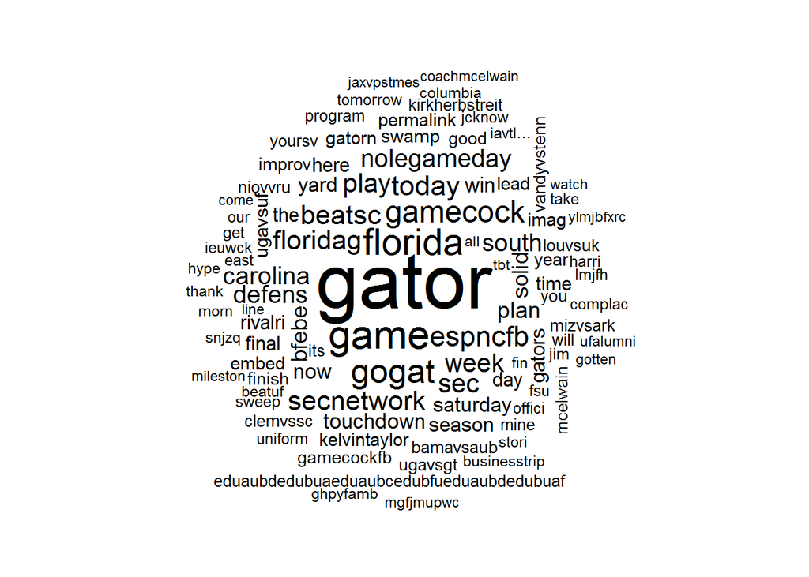

```r
TweetCloud <- GameTweets$text
TweetCloud <- gsub("(f|ht)tp(s?)://(.*)[.][a-z0-9/]+", "", TweetCloud)
TweetCloud <- Corpus(VectorSource(TweetCloud))
TweetCloud <- tm_map(TweetCloud, PlainTextDocument)
TweetCloud <- tm_map(TweetCloud, removePunctuation)
TweetCloud <- tm_map(TweetCloud, removeNumbers)
TweetCloud <- tm_map(TweetCloud, removeWords, c('the', 'this', stopwords('english')))
TweetCloud <- tm_map(TweetCloud, removeWords, c('GatorsFB', 'FSUvsUF', 'UFvsSC', 'character0'))
TweetCloud <- tm_map(TweetCloud, stemDocument)
wordcloud(TweetCloud, max.words = 100, random.order = FALSE)
```

**Results:** This will take a lot more work on the text cleanup process before it shows anything of value. Unfortunately I ran out of time, and was not able to finish the text clean up. I did however learn a lot about text processing in working on this section. Even though it is not complete, I’ve included it here just for fun.

Back to Top

## Creating the data set for predictive analysis.

In the following code block the data is manipulated into the final `Sentiment` dataframe we will use for analysis. The steps used to create this dataframe are as follows.

1. Create dataframe `Sentiment` from original `GameTweets` dataframe.
2. Add in the results from the `classify_polarity` analysis.
3. Add in the results from the `classify_emotion` analysis.
4. Join game results data from `Shed` frame.

```r
## This code block is designed to create a `Sentiment` dataframe for use in our sentiment analysis.  Once this dataframe is created it will be saved for later use, and reloaded when needed.  This frame will not be evaluated during knitting.

## Create a dataframe `Sentiment` to hold the polarity classifiers. Save this dataframe so it can be reloaded in later iterations.  This will save time in processing.
Sentiment <- GameTweets

## Add in the polarity clasifiers.
polarity.cf <- as.data.frame(classify_polarity(Sentiment$text))
save (polarity.cf, file="polarity.RData")
load ("../FinalProject/polarity.RData")

## Bind the polarity classifier back to the original `Sentiment` data set.
Sentiment <- cbind(Sentiment, polarity.cf)
Sentiment <- rename(Sentiment, SBEST_FIT = BEST_FIT)

## Add in the emotion classifiers
emotion.cf <- as.data.frame(classify_emotion(Sentiment$text))
emotion.cf <- rename(emotion.cf, EBEST_FIT = BEST_FIT)
save (emotion.cf, file="emotion.RData")
load ("../FinalProject/emotion.RData")

## Bind the emotion classifiers back to the original GameTweets data set
Sentiment <- cbind(Sentiment, emotion.cf)
Sentiment <- rename(Sentiment, GAMEDATE = DATE)

## Joining the `Sentiment` dataframe to the `sched` data frame.
Sentiment <- left_join(Sentiment, Sched, by="Game")
## save (Sentiment, file="Sentiment.RData")  ## This line is commented out to prevent execution during testing.
```

```r
load ("../FinalProject/Sentiment.RData")

## The columns in the dataset
names(Sentiment)
```

```
##  [1] "Game"       "screenName" "date"       "text"       "POS"
##  [6] "NEG"        "POS/NEG"    "SBEST_FIT"  "ANGER"      "DISGUST"
## [11] "FEAR"       "JOY"        "SADNESS"    "SURPRISE"   "EBEST_FIT"
## [16] "GAMEDATE"   "OPPONENT"   "H.A"        "RESULT"     "UFSCORE"
## [21] "OSCORE"     "MARGIN"     "SPREAD"     "COVER"      "BEAT"
## [26] "HASHTAG"
```

```r
## A view of the data
kable(Sentiment[1:5, ], digits=2, caption="The Full Dataframe with Sentiment and Game Data", format = "html")
```

The Full Dataframe with Sentiment and Game Data

| Game | screenName | date | text | POS | NEG | POS/NEG | SBEST_FIT | ANGER | DISGUST | FEAR | JOY | SADNESS | SURPRISE | EBEST_FIT | GAMEDATE | OPPONENT | H.A | RESULT | UFSCORE | OSCORE | MARGIN | SPREAD | COVER | BEAT | HASHTAG |
| --- | --- | --- | --- | --- | --- | --- | --- | --- | --- | --- | --- | --- | --- | --- | --- | --- | --- | --- | --- | --- | --- | --- | --- | --- | --- |
| Game01 | TraceyJ305 | 2015-09-04 | Florida, USA Yep, I’m ready. See you all in The Swamp tomorrow! ððð¶ #ItsGreatUF #swamp1#NMSUvsUF @uf @GatorsFB Embedded image permalink | 24.9775602759011 | 9.47547003995745 | 2.63602334982563 | positive | 1.46871776464786 | 3.09234031207392 | 2.06783599555953 | 1.02547755260094 | 1.7277074477352 | 2.78695866252273 | NA | 2015-09-05 | New Mexico State | H | W | 61 | 13 | 48 | -34 | 14 | yes | NMSUvsUF |
| Game01 | JoeUFL | 2015-09-04 | The calm before the storm! I can’t wait for @FloridaGators @GatorsFB! @UF #GoGators #Swamp1#NMSUvsUF #SECFootball Embedded image permalink | 8.78232285939751 | 8.78232285939751 | 1 | neutral | 1.46871776464786 | 3.09234031207392 | 2.06783599555953 | 1.02547755260094 | 1.7277074477352 | 2.78695866252273 | NA | 2015-09-05 | New Mexico State | H | W | 61 | 13 | 48 | -34 | 14 | yes | NMSUvsUF |
| Game01 | GatorsSC | 2015-09-04 | 2hoursâ¦ #NMSUvsUF Embedded image permalink | 1.03127774142571 | 0.445453222112551 | 2.31512017476245 | positive | 1.46871776464786 | 3.09234031207392 | 2.06783599555953 | 1.02547755260094 | 1.7277074477352 | 2.78695866252273 | NA | 2015-09-05 | New Mexico State | H | W | 61 | 13 | 48 | -34 | 14 | yes | NMSUvsUF |
| Game01 | robinrandrews | 2015-09-04 | Tin Tebow is so ready for some @UF football. #NMSUvsUF #ItsGreatUF Embedded image permalink | 8.78232285939751 | 0.445453222112551 | 19.7154772340574 | positive | 1.46871776464786 | 3.09234031207392 | 2.06783599555953 | 1.02547755260094 | 1.7277074477352 | 2.78695866252273 | NA | 2015-09-05 | New Mexico State | H | W | 61 | 13 | 48 | -34 | 14 | yes | NMSUvsUF |
| Game01 | jneamarie | 2015-09-04 | @GatorsFB starts in 2hours and 5minutes… Can you tell I’m excited? #NMSUvsUF #ItsGreatUF ð¸ðð¹ | 9.47547003995745 | 0.445453222112551 | 21.2715265477714 | positive | 1.46871776464786 | 3.09234031207392 | 2.06783599555953 | 1.02547755260094 | 1.7277074477352 | 2.78695866252273 | NA | 2015-09-05 | New Mexico State | H | W | 61 | 13 | 48 | -34 | 14 | yes | NMSUvsUF |

```r
## Sumarize the data
summary(Sentiment)
```

```
##      Game            screenName             date
##  Length:25846       Length:25846       Min.   :2015-08-31
##  Class :character   Class :character   1st Qu.:2015-11-14
##  Mode  :character   Mode  :character   Median :2015-11-14
##                                        Mean   :2015-11-13
##                                        3rd Qu.:2015-11-18
##                                        Max.   :2015-11-27
##                                        NA's   :26
##      text                         POS                       NEG
##  Length:25846       1.03127774142571:12607   0.445453222112551:16715
##  Class :character   8.78232285939751: 4888   8.78232285939751 : 5160
##  Mode  :character   9.47547003995745: 4342   9.47547003995745 : 2690
##                     16.5333679773693: 2191   18.5054868578024 :  506
##                     17.2265151579293:  775   17.8123396772424 :  353
##                     17.9196623384892:  638   17.1191924966825 :  189
##                     (Other)         :  405   (Other)          :  233
##               POS/NEG        SBEST_FIT                  ANGER
##  2.31512017476245 :9279   negative: 4516   1.46871776464786:25392
##  19.7154772340574 :3253   neutral : 4387   13.2129533435987:    5
##  21.2715265477714 :2476   positive:16943   7.34083555412328:  449
##  0.117426534862834:1595
##  1.88257346513717 :1408
##  1                :1387
##  (Other)          :6448
##              DISGUST                    FEAR
##  3.09234031207392:25801   2.06783599555953:25753
##  7.34083555412328:   45   7.34083555412328:   93
##
##
##
##
##
##                JOY                    SADNESS
##  1.02547755260094:21962   1.7277074477352 :25242
##  13.6561935556456:   90   12.9539636605113:    8
##  19.9715515571679:    4   7.34083555412328:  596
##  26.2869095586903:    1
##  38.917625561735 :    1
##  7.34083555412328: 3788
##
```

[output cut: 17 more lines]

```
##  Min.   : 3.00   Min.   :-25.000   Min.   :-34.00   Min.   :-22.50
##  1st Qu.:14.00   1st Qu.:  2.000   1st Qu.:-28.50   1st Qu.:-22.50
##  Median :14.00   Median :  6.000   Median : -7.00   Median :-22.50
##  Mean   :16.69   Mean   :  1.449   Mean   :-11.76   Mean   :-10.31
##  3rd Qu.:24.00   3rd Qu.: 10.000   3rd Qu.:  1.00   3rd Qu.:  3.00
##  Max.   :35.00   Max.   : 48.000   Max.   : 11.50   Max.   : 34.50
##
##   BEAT           HASHTAG
##  no :15142   FAUvsUF :8714
##  yes:10704   UFvsSC  :8677
##              FSUvsUF :5592
##              UFvsUGA :1232
##              UFvsLSU : 419
##              TENNvsUF: 374
##              (Other) : 838
```

## Subjectivity Analysis

The Subjectivity analysis uses the `classify_polarity` function to compare the text in each tweet looking for positive vs. negative polarity. This function uses a naive Bayes classifier trained on Janyce Wiebe’s subjectivity lexicon (source: R Documentation).

### Best Fit

The `classify_polarity` function creates a positive, neutral, and negative score as well as a best fit identifier for each of the tweets in our database.

```r
## Best Fit Subjectivites
BestFitSubjectivity <- Sentiment %>% count(SBEST_FIT)
kable(BestFitSubjectivity, caption="Total tweets by Best Fit Subjectivity")
```

Total tweets by Best Fit Subjectivity

| SBEST_FIT | n |
| --- | --- |
| negative | 4516 |
| neutral | 4387 |
| positive | 16943 |

Back to Top

### Subjectivity by Game

We will use `group_by` and `summarize` to find the fraction of tweets that are positive, neutral and negative for each game and game/date combination.

```r
## Create a new dataframe `polarity.sum` to hold the summary table.
polarity.sum <- Sentiment %>%
  group_by(Game) %>%
  summarize(Positive = sum(SBEST_FIT=="positive"),
            Neutral = sum(SBEST_FIT=="neutral"),
            Negative = sum(SBEST_FIT=="negative"),
            Total = n(),
            PosFrac = sum(SBEST_FIT=="positive")/n(),
            NeutFrac = sum(SBEST_FIT=="neutral")/n(),
            NegFrac = sum(SBEST_FIT=="negative")/n())



## Sort the dataframe by PosFrac so that output will display positive polarity by Game.
polarity.sum <- polarity.sum[order(-polarity.sum$PosFrac),]
kable(polarity.sum, digits=2, caption="Subjectivity Analysis by Game, in decending order by Positive Fraction")
```

Subjectivity Analysis by Game, in decending order by Positive Fraction

| Game | Positive | Neutral | Negative | Total | PosFrac | NeutFrac | NegFrac |
| --- | --- | --- | --- | --- | --- | --- | --- |
| Game11 | 6486 | 757 | 1471 | 8714 | 0.74 | 0.09 | 0.17 |
| Game09 | 202 | 29 | 81 | 312 | 0.65 | 0.09 | 0.26 |
| Game10 | 5536 | 1862 | 1279 | 8677 | 0.64 | 0.21 | 0.15 |
| Game08 | 765 | 176 | 291 | 1232 | 0.62 | 0.14 | 0.24 |
| Game01 | 46 | 15 | 14 | 75 | 0.61 | 0.20 | 0.19 |
| Game04 | 222 | 49 | 103 | 374 | 0.59 | 0.13 | 0.28 |
| Game06 | 46 | 10 | 22 | 78 | 0.59 | 0.13 | 0.28 |
| Game03 | 68 | 22 | 27 | 117 | 0.58 | 0.19 | 0.23 |
| Game07 | 243 | 63 | 113 | 419 | 0.58 | 0.15 | 0.27 |
| Game12 | 3194 | 1361 | 1037 | 5592 | 0.57 | 0.24 | 0.19 |
| Game02 | 56 | 19 | 30 | 105 | 0.53 | 0.18 | 0.29 |
| Game05 | 79 | 24 | 48 | 151 | 0.52 | 0.16 | 0.32 |

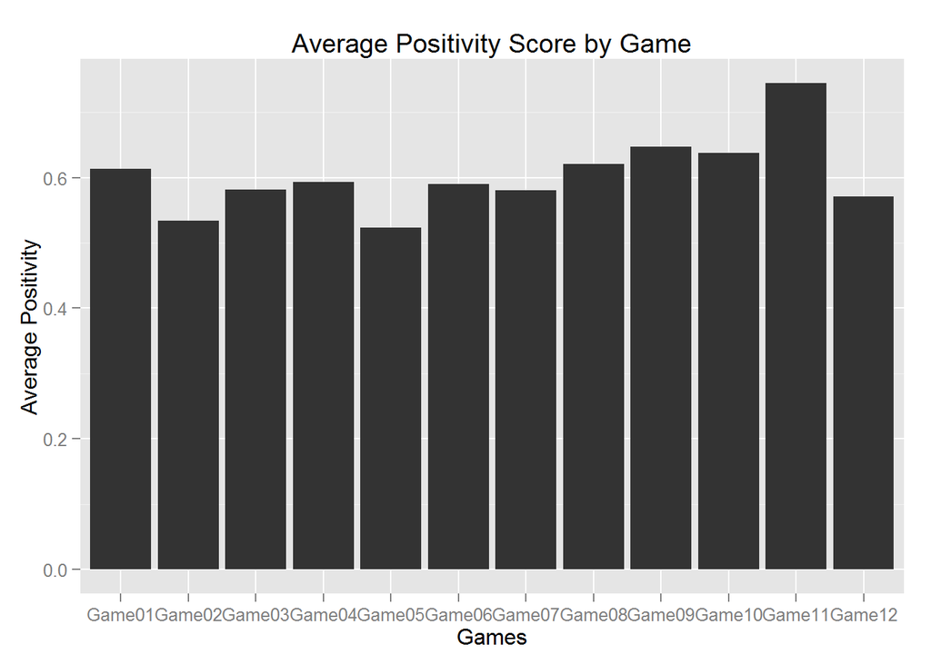

```r
## Plot the average positivity score by game
qplot(Game, PosFrac, data=polarity.sum,
      main = "Average Positivity Score by Game",
      xlab = "Games",
      ylab = "Average Positivity",
      geom = "bar",
      binwidth = 0.1,
      stat="identity") ##,  ylim = c(0.4,0.8)
```

```r
## Sort the dataframe by NegFrac so that output will display negative polarity by Game.
polarity.sum <- polarity.sum[order(-polarity.sum$NegFrac),]
kable(polarity.sum, digits=2, caption="Subjectivity Analysis by Game, in decending order by Negative Fraction")
```

Subjectivity Analysis by Game, in decending order by Negative Fraction

| Game | Positive | Neutral | Negative | Total | PosFrac | NeutFrac | NegFrac |
| --- | --- | --- | --- | --- | --- | --- | --- |
| Game05 | 79 | 24 | 48 | 151 | 0.52 | 0.16 | 0.32 |
| Game02 | 56 | 19 | 30 | 105 | 0.53 | 0.18 | 0.29 |
| Game06 | 46 | 10 | 22 | 78 | 0.59 | 0.13 | 0.28 |
| Game04 | 222 | 49 | 103 | 374 | 0.59 | 0.13 | 0.28 |
| Game07 | 243 | 63 | 113 | 419 | 0.58 | 0.15 | 0.27 |
| Game09 | 202 | 29 | 81 | 312 | 0.65 | 0.09 | 0.26 |
| Game08 | 765 | 176 | 291 | 1232 | 0.62 | 0.14 | 0.24 |
| Game03 | 68 | 22 | 27 | 117 | 0.58 | 0.19 | 0.23 |
| Game01 | 46 | 15 | 14 | 75 | 0.61 | 0.20 | 0.19 |
| Game12 | 3194 | 1361 | 1037 | 5592 | 0.57 | 0.24 | 0.19 |
| Game11 | 6486 | 757 | 1471 | 8714 | 0.74 | 0.09 | 0.17 |
| Game10 | 5536 | 1862 | 1279 | 8677 | 0.64 | 0.21 | 0.15 |

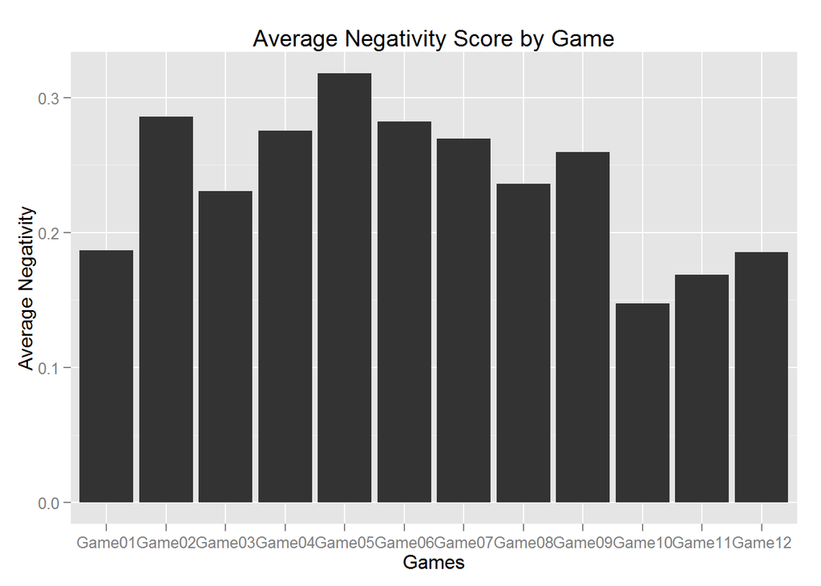

```r
## Plot the average negativity score by game
qplot(Game, NegFrac, data=polarity.sum,
      main = "Average Negativity Score by Game",
      xlab = "Games",
      ylab = "Average Negativity",
      geom = c("bar"),
      binwidth = 1,
      stat="identity")
```

Back to Top

### Subjectivity by Game and Date

Now let’s look at Subjectivity analysis by game and by date to see how the Subjectivities change over the week leading up to the game. This is much more all over the place

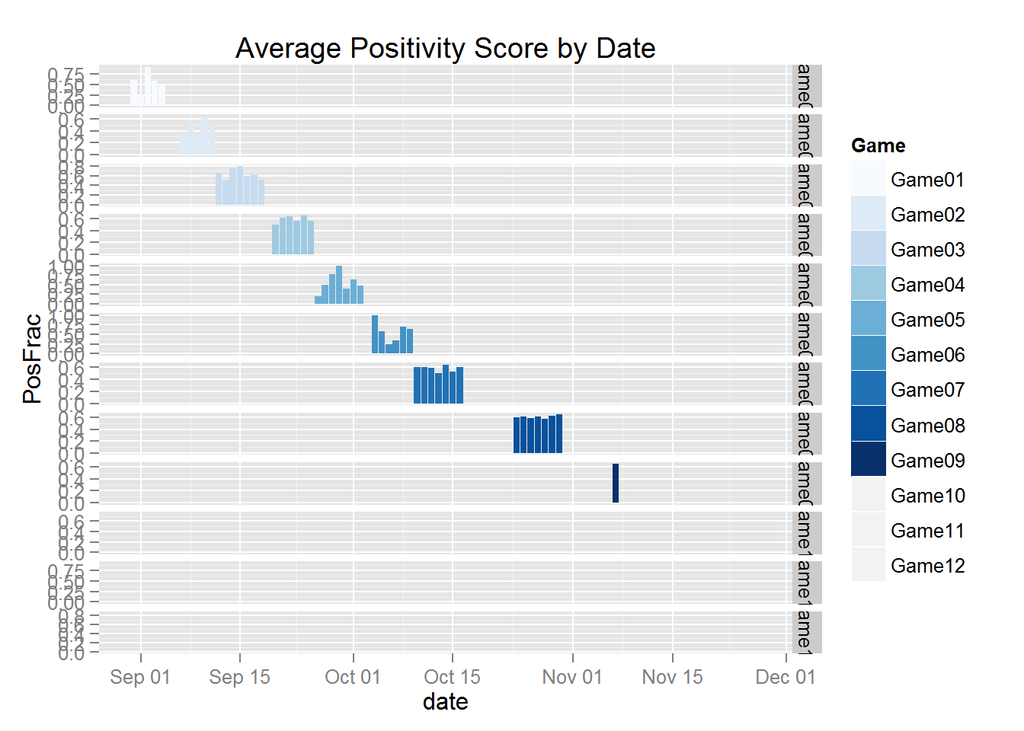

```r
## Create a new dataframe `polarity.sum` to hold the summary table
polarity.sum <- Sentiment %>%
  group_by(date, Game) %>%
  summarize(Positive = sum(SBEST_FIT=="positive"),
            Neutral = sum(SBEST_FIT=="neutral"),
            Negative = sum(SBEST_FIT=="negative"),
            Total = n(),
            PosFrac = sum(SBEST_FIT=="positive")/n(),
            NeutFrac = sum(SBEST_FIT=="neutral")/n(),
            NegFrac = sum(SBEST_FIT=="negative")/n())

## Sort the dataframe by date and game so that we can see how polarity changes over time.
polarity.sum <- polarity.sum[order(polarity.sum$date, polarity.sum$Game),]

## Plot the average positivity score by game & by day
ggplot(polarity.sum, aes(x= date, y=PosFrac, fill=Game, order=desc(Game))) +
  ggtitle ("Average Positivity Score by Date") +
  geom_bar(stat="identity") +
  scale_fill_brewer(palette=1) +
  facet_grid (Game ~ ., scales="free")
```

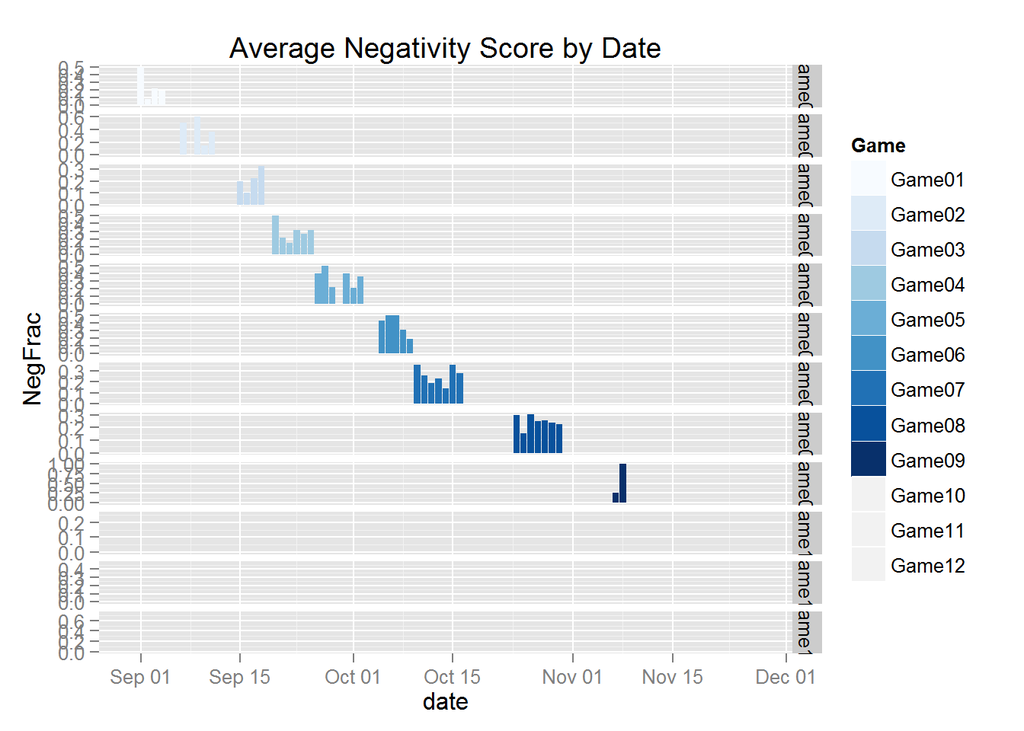

```r
## Plot the average negativity score by game & by day
ggplot(polarity.sum, aes(x=date, y=NegFrac, fill=Game, order=desc(Game))) +
  ggtitle ("Average Negativity Score by Date") +
  geom_bar(stat="identity") +
  scale_fill_brewer(palette=1) +
  facet_grid (Game ~ ., scales="free")
```

```r
kable(polarity.sum, digits=2, caption="Subjectivity Analysis by Game & Day")
```

Subjectivity Analysis by Game & Day

| date | Game | Positive | Neutral | Negative | Total | PosFrac | NeutFrac | NegFrac |
| --- | --- | --- | --- | --- | --- | --- | --- | --- |
| 2015-08-31 | Game01 | 3 | 2 | 0 | 5 | 0.60 | 0.40 | 0.00 |
| 2015-09-01 | Game01 | 1 | 1 | 2 | 4 | 0.25 | 0.25 | 0.50 |
| 2015-09-02 | Game01 | 12 | 0 | 1 | 13 | 0.92 | 0.00 | 0.08 |
| 2015-09-03 | Game01 | 19 | 6 | 7 | 32 | 0.59 | 0.19 | 0.22 |
| 2015-09-04 | Game01 | 11 | 6 | 4 | 21 | 0.52 | 0.29 | 0.19 |
| 2015-09-07 | Game02 | 2 | 1 | 3 | 6 | 0.33 | 0.17 | 0.50 |
| 2015-09-08 | Game02 | 4 | 3 | 0 | 7 | 0.57 | 0.43 | 0.00 |
| 2015-09-09 | Game02 | 3 | 1 | 6 | 10 | 0.30 | 0.10 | 0.60 |
| 2015-09-10 | Game02 | 26 | 9 | 6 | 41 | 0.63 | 0.22 | 0.15 |
| 2015-09-11 | Game02 | 21 | 5 | 15 | 41 | 0.51 | 0.12 | 0.37 |
| 2015-09-12 | Game03 | 2 | 1 | 0 | 3 | 0.67 | 0.33 | 0.00 |
| 2015-09-13 | Game03 | 1 | 1 | 0 | 2 | 0.50 | 0.50 | 0.00 |
| 2015-09-14 | Game03 | 3 | 1 | 0 | 4 | 0.75 | 0.25 | 0.00 |
| 2015-09-15 | Game03 | 4 | 0 | 1 | 5 | 0.80 | 0.00 | 0.20 |
| 2015-09-16 | Game03 | 12 | 6 | 2 | 20 | 0.60 | 0.30 | 0.10 |
| 2015-09-17 | Game03 | 19 | 5 | 7 | 31 | 0.61 | 0.16 | 0.23 |
| 2015-09-18 | Game03 | 27 | 8 | 17 | 52 | 0.52 | 0.15 | 0.33 |
| 2015-09-20 | Game04 | 2 | 0 | 2 | 4 | 0.50 | 0.00 | 0.50 |
| 2015-09-21 | Game04 | 29 | 8 | 10 | 47 | 0.62 | 0.17 | 0.21 |
| 2015-09-22 | Game04 | 26 | 9 | 6 | 41 | 0.63 | 0.22 | 0.15 |
| 2015-09-23 | Game04 | 32 | 7 | 18 | 57 | 0.56 | 0.12 | 0.32 |
| 2015-09-24 | Game04 | 53 | 7 | 22 | 82 | 0.65 | 0.09 | 0.27 |
| 2015-09-25 | Game04 | 80 | 18 | 45 | 143 | 0.56 | 0.13 | 0.31 |
| 2015-09-26 | Game05 | 1 | 2 | 2 | 5 | 0.20 | 0.40 | 0.40 |
| 2015-09-27 | Game05 | 2 | 0 | 2 | 4 | 0.50 | 0.00 | 0.50 |
| 2015-09-28 | Game05 | 7 | 0 | 2 | 9 | 0.78 | 0.00 | 0.22 |
| 2015-09-29 | Game05 | 2 | 0 | 0 | 2 | 1.00 | 0.00 | 0.00 |
| 2015-09-30 | Game05 | 4 | 2 | 4 | 10 | 0.40 | 0.20 | 0.40 |
| 2015-10-01 | Game05 | 21 | 5 | 7 | 33 | 0.64 | 0.15 | 0.21 |
| 2015-10-02 | Game05 | 42 | 15 | 31 | 88 | 0.48 | 0.17 | 0.35 |
| 2015-10-04 | Game06 | 2 | 0 | 0 | 2 | 1.00 | 0.00 | 0.00 |
| 2015-10-05 | Game06 | 4 | 0 | 3 | 7 | 0.57 | 0.00 | 0.43 |
| 2015-10-06 | Game06 | 2 | 2 | 4 | 8 | 0.25 | 0.25 | 0.50 |
| 2015-10-07 | Game06 | 2 | 1 | 3 | 6 | 0.33 | 0.17 | 0.50 |
| 2015-10-08 | Game06 | 9 | 0 | 4 | 13 | 0.69 | 0.00 | 0.31 |
| 2015-10-09 | Game06 | 27 | 7 | 8 | 42 | 0.64 | 0.17 | 0.19 |
| 2015-10-10 | Game07 | 15 | 1 | 9 | 25 | 0.60 | 0.04 | 0.36 |
| 2015-10-11 | Game07 | 25 | 6 | 11 | 42 | 0.60 | 0.14 | 0.26 |
| 2015-10-12 | Game07 | 28 | 11 | 9 | 48 | 0.58 | 0.23 | 0.19 |
| 2015-10-13 | Game07 | 13 | 7 | 6 | 26 | 0.50 | 0.27 | 0.23 |
| 2015-10-14 | Game07 | 28 | 10 | 6 | 44 | 0.64 | 0.23 | 0.14 |
| 2015-10-15 | Game07 | 42 | 10 | 29 | 81 | 0.52 | 0.12 | 0.36 |
| 2015-10-16 | Game07 | 92 | 18 | 43 | 153 | 0.60 | 0.12 | 0.28 |
| 2015-10-24 | Game08 | 6 | 1 | 3 | 10 | 0.60 | 0.10 | 0.30 |
| 2015-10-25 | Game08 | 20 | 8 | 5 | 33 | 0.61 | 0.24 | 0.15 |
| 2015-10-26 | Game08 | 50 | 10 | 26 | 86 | 0.58 | 0.12 | 0.30 |
| 2015-10-27 | Game08 | 70 | 16 | 29 | 115 | 0.61 | 0.14 | 0.25 |
| 2015-10-28 | Game08 | 83 | 24 | 37 | 144 | 0.58 | 0.17 | 0.26 |
| 2015-10-29 | Game08 | 208 | 47 | 80 | 335 | 0.62 | 0.14 | 0.24 |
| 2015-10-30 | Game08 | 313 | 62 | 108 | 483 | 0.65 | 0.13 | 0.22 |
| 2015-11-07 | Game09 | 202 | 29 | 80 | 311 | 0.65 | 0.09 | 0.26 |
| 2015-11-08 | Game09 | 0 | 0 | 1 | 1 | 0.00 | 0.00 | 1.00 |
| 2015-11-12 | Game10 | 482 | 38 | 127 | 647 | 0.74 | 0.06 | 0.20 |
| 2015-11-13 | Game10 | 574 | 37 | 210 | 821 | 0.70 | 0.05 | 0.26 |
| 2015-11-13 | Game11 | 4 | 1 | 1 | 6 | 0.67 | 0.17 | 0.17 |
| 2015-11-14 | Game10 | 4370 | 1636 | 901 | 6907 | 0.63 | 0.24 | 0.13 |
| 2015-11-14 | Game11 | 4062 | 439 | 620 | 5121 | 0.79 | 0.09 | 0.12 |
| 2015-11-15 | Game10 | 110 | 151 | 41 | 302 | 0.36 | 0.50 | 0.14 |
| 2015-11-15 | Game11 | 571 | 149 | 181 | 901 | 0.63 | 0.17 | 0.20 |
| 2015-11-16 | Game11 | 372 | 62 | 379 | 813 | 0.46 | 0.08 | 0.47 |
| 2015-11-17 | Game11 | 809 | 17 | 58 | 884 | 0.92 | 0.02 | 0.07 |
| 2015-11-18 | Game11 | 463 | 41 | 83 | 587 | 0.79 | 0.07 | 0.14 |
| 2015-11-19 | Game11 | 205 | 48 | 149 | 402 | 0.51 | 0.12 | 0.37 |
| 2015-11-21 | Game12 | 7 | 5 | 11 | 23 | 0.30 | 0.22 | 0.48 |
| 2015-11-22 | Game12 | 20 | 9 | 84 | 113 | 0.18 | 0.08 | 0.74 |
| 2015-11-23 | Game12 | 172 | 483 | 241 | 896 | 0.19 | 0.54 | 0.27 |
| 2015-11-24 | Game12 | 301 | 590 | 53 | 944 | 0.32 | 0.62 | 0.06 |
| 2015-11-25 | Game12 | 235 | 103 | 341 | 679 | 0.35 | 0.15 | 0.50 |
| 2015-11-26 | Game12 | 285 | 66 | 34 | 385 | 0.74 | 0.17 | 0.09 |
| 2015-11-27 | Game12 | 2174 | 105 | 273 | 2552 | 0.85 | 0.04 | 0.11 |
| NA | Game08 | 15 | 8 | 3 | 26 | 0.58 | 0.31 | 0.12 |

**Results:** This analysis is still not quite doing what I hoped it would do. I need to develop a way to match up the games in the faceted chart. I can do this by creating a new column in the data set for day which would be date - game date. This will be future analysis.

Back to Top

## Emotion Analysis

The Emotion analysis uses the `classify_emotion` function to compare the text in each tweet looking for words that correlate with emotions (e.g. anger, disgust, fear, joy, sadness and surprise). This function uses a naive Bayes classifier trained on Carlo Strapparava and Alessandro Valitutti’s emotions lexicon (source: R Documentation).

### Expressions of Emotion

We’ll start by calculating the emotions for each of our tweets. In addition, we add a Best Fit identifier to each tweet indicating which of the emotions best indicates its overall Emotional expression.

```r
## Best Fit Emotions
BestFitEmotion <- Sentiment %>% count(EBEST_FIT)
kable(BestFitEmotion, caption="Emotion Analysis: The number of tweet in each Best Fit Category")
```

Emotion Analysis: The number of tweet in each Best Fit Category

| EBEST_FIT | n |
| --- | --- |
| anger | 452 |
| disgust | 44 |
| fear | 81 |
| joy | 3830 |
| sadness | 452 |
| surprise | 282 |
| NA | 20705 |

Back to Top

### Emotion by Game

Now let’s look at how sentiments differ by game. We’ll use the `group_by` and `summarize` functions to find the fraction of tweets that align with each emotion. These tables give an indication of the strength of emotion for each of the games.

```r
## Create a new dataframe `emotion.df` to hold the summary table.
emotion.sum <- Sentiment %>%
  group_by(Game) %>%
  summarize(ANGER = sum(ANGER)/n(),
            DISGUST = sum(DISGUST)/n(),
            FEAR = sum(FEAR)/n(),
            JOY = sum(JOY)/n(),
            SADNESS = sum(SADNESS)/n(),
            SURPRISE = sum(SURPRISE)/n())

## Sort the dataframe by total so that output will display in Game order.
emotion.sum <- emotion.sum[order(emotion.sum$Game),]
kable(emotion.sum, digits=2, caption="Emotion Analysis by Game")
```

Emotion Analysis by Game

| Game | ANGER | DISGUST | FEAR | JOY | SADNESS | SURPRISE |
| --- | --- | --- | --- | --- | --- | --- |
| Game01 | 1.00 | 1.00 | 1.00 | 1.40 | 1.16 | 2.07 |
| Game02 | 1.00 | 1.00 | 1.00 | 1.86 | 1.13 | 2.10 |
| Game03 | 1.02 | 1.00 | 1.00 | 1.40 | 1.07 | 2.03 |
| Game04 | 1.03 | 1.01 | 1.01 | 1.57 | 1.19 | 2.08 |
| Game05 | 1.01 | 1.00 | 1.00 | 2.01 | 1.08 | 2.07 |
| Game06 | 1.05 | 1.00 | 1.03 | 1.83 | 1.12 | 2.06 |
| Game07 | 1.06 | 1.00 | 1.02 | 1.50 | 1.11 | 2.10 |
| Game08 | 1.03 | 1.00 | 1.01 | 1.70 | 1.10 | 2.06 |
| Game09 | 1.11 | 1.01 | 1.06 | 2.03 | 1.10 | 2.05 |
| Game10 | 1.02 | 1.00 | 1.00 | 1.70 | 1.04 | 2.02 |
| Game11 | 1.06 | 1.00 | 1.00 | 1.40 | 1.05 | 2.07 |
| Game12 | 1.01 | 1.00 | 1.00 | 2.34 | 1.02 | 2.01 |

```r
## Sort the dataframe by total so that output will display the output in decending order by joy.
emotion.sum <- emotion.sum[order(-emotion.sum$JOY),]
mostjoy <- emotion.sum$date[1]
kable(emotion.sum[1:10, ], digits=2, caption="Emotion Analysis by Game in decending order by Joy")
```

Emotion Analysis by Game in decending order by Joy

| Game | ANGER | DISGUST | FEAR | JOY | SADNESS | SURPRISE |
| --- | --- | --- | --- | --- | --- | --- |
| Game12 | 1.01 | 1.00 | 1.00 | 2.34 | 1.02 | 2.01 |
| Game09 | 1.11 | 1.01 | 1.06 | 2.03 | 1.10 | 2.05 |
| Game05 | 1.01 | 1.00 | 1.00 | 2.01 | 1.08 | 2.07 |
| Game02 | 1.00 | 1.00 | 1.00 | 1.86 | 1.13 | 2.10 |
| Game06 | 1.05 | 1.00 | 1.03 | 1.83 | 1.12 | 2.06 |
| Game10 | 1.02 | 1.00 | 1.00 | 1.70 | 1.04 | 2.02 |
| Game08 | 1.03 | 1.00 | 1.01 | 1.70 | 1.10 | 2.06 |
| Game04 | 1.03 | 1.01 | 1.01 | 1.57 | 1.19 | 2.08 |
| Game07 | 1.06 | 1.00 | 1.02 | 1.50 | 1.11 | 2.10 |
| Game03 | 1.02 | 1.00 | 1.00 | 1.40 | 1.07 | 2.03 |

```r
## Sort the dataframe by total so that output will display the output in decending order by joy.
emotion.sum <- emotion.sum[order(-emotion.sum$SADNESS),]
mostjoy <- emotion.sum$date[1]
kable(emotion.sum[1:10, ], digits=2, caption="Emotion Analysis by Game in decending order by Saddness")
```

Emotion Analysis by Game in decending order by Saddness

| Game | ANGER | DISGUST | FEAR | JOY | SADNESS | SURPRISE |
| --- | --- | --- | --- | --- | --- | --- |
| Game04 | 1.03 | 1.01 | 1.01 | 1.57 | 1.19 | 2.08 |
| Game01 | 1.00 | 1.00 | 1.00 | 1.40 | 1.16 | 2.07 |
| Game02 | 1.00 | 1.00 | 1.00 | 1.86 | 1.13 | 2.10 |
| Game06 | 1.05 | 1.00 | 1.03 | 1.83 | 1.12 | 2.06 |
| Game07 | 1.06 | 1.00 | 1.02 | 1.50 | 1.11 | 2.10 |
| Game09 | 1.11 | 1.01 | 1.06 | 2.03 | 1.10 | 2.05 |
| Game08 | 1.03 | 1.00 | 1.01 | 1.70 | 1.10 | 2.06 |
| Game05 | 1.01 | 1.00 | 1.00 | 2.01 | 1.08 | 2.07 |
| Game03 | 1.02 | 1.00 | 1.00 | 1.40 | 1.07 | 2.03 |
| Game11 | 1.06 | 1.00 | 1.00 | 1.40 | 1.05 | 2.07 |

Back to Top

### Emotion by Game and Date

```r
## Create a new dataframe `emotion.df` to hold the summary table.
emotion.sum <- Sentiment %>%
  group_by(date, Game) %>%
  summarize(ANGER = sum(ANGER)/n(),
            DISGUST = sum(DISGUST)/n(),
            FEAR = sum(FEAR)/n(),
            JOY = sum(JOY)/n(),
            SADNESS = sum(SADNESS)/n(),
            SURPRISE = sum(SURPRISE)/n())

## Sort the dataframe by total so that output will display the most active tweeters at the top.
emotion.sum <- emotion.sum[order(emotion.sum$date, emotion.sum$Game),]
kable(emotion.sum, digits=2, caption="Emotion Analysis by Game & Day")
```

Emotion Analysis by Game & Day

| date | Game | ANGER | DISGUST | FEAR | JOY | SADNESS | SURPRISE |
| --- | --- | --- | --- | --- | --- | --- | --- |
| 2015-08-31 | Game01 | 1.00 | 1.00 | 1.00 | 1.00 | 1.40 | 2.20 |
| 2015-09-01 | Game01 | 1.00 | 1.00 | 1.00 | 2.25 | 1.00 | 2.00 |
| 2015-09-02 | Game01 | 1.00 | 1.00 | 1.00 | 1.38 | 1.00 | 2.00 |
| 2015-09-03 | Game01 | 1.00 | 1.00 | 1.00 | 1.31 | 1.19 | 2.09 |
| 2015-09-04 | Game01 | 1.00 | 1.00 | 1.00 | 1.48 | 1.19 | 2.05 |
| 2015-09-07 | Game02 | 1.00 | 1.00 | 1.00 | 1.83 | 1.33 | 2.00 |
| 2015-09-08 | Game02 | 1.00 | 1.00 | 1.00 | 1.00 | 1.00 | 2.14 |
| 2015-09-09 | Game02 | 1.00 | 1.00 | 1.00 | 2.50 | 1.00 | 2.10 |
| 2015-09-10 | Game02 | 1.00 | 1.00 | 1.00 | 1.37 | 1.10 | 2.07 |
| 2015-09-11 | Game02 | 1.00 | 1.00 | 1.00 | 2.34 | 1.20 | 2.12 |
| 2015-09-12 | Game03 | 1.00 | 1.00 | 1.00 | 1.00 | 1.00 | 2.00 |
| 2015-09-13 | Game03 | 1.00 | 1.00 | 1.00 | 3.50 | 1.00 | 2.00 |
| 2015-09-14 | Game03 | 1.00 | 1.00 | 1.00 | 1.00 | 1.00 | 2.00 |
| 2015-09-15 | Game03 | 1.00 | 1.00 | 1.00 | 1.00 | 1.00 | 2.00 |
| 2015-09-16 | Game03 | 1.00 | 1.00 | 1.00 | 1.30 | 1.30 | 2.05 |
| 2015-09-17 | Game03 | 1.06 | 1.00 | 1.00 | 1.65 | 1.00 | 2.06 |
| 2015-09-18 | Game03 | 1.00 | 1.00 | 1.00 | 1.31 | 1.04 | 2.02 |
| 2015-09-20 | Game04 | 1.00 | 1.00 | 1.00 | 1.00 | 1.50 | 2.25 |
| 2015-09-21 | Game04 | 1.09 | 1.00 | 1.02 | 1.64 | 1.32 | 2.09 |
| 2015-09-22 | Game04 | 1.00 | 1.02 | 1.00 | 1.15 | 1.20 | 2.02 |
| 2015-09-23 | Game04 | 1.00 | 1.02 | 1.02 | 1.70 | 1.25 | 2.07 |
| 2015-09-24 | Game04 | 1.02 | 1.00 | 1.00 | 1.49 | 1.02 | 2.07 |
| 2015-09-25 | Game04 | 1.04 | 1.00 | 1.00 | 1.68 | 1.20 | 2.10 |
| 2015-09-26 | Game05 | 1.00 | 1.00 | 1.00 | 2.00 | 1.40 | 2.20 |
| 2015-09-27 | Game05 | 1.00 | 1.00 | 1.00 | 1.00 | 1.00 | 2.00 |
| 2015-09-28 | Game05 | 1.00 | 1.00 | 1.00 | 2.22 | 1.00 | 2.11 |
| 2015-09-29 | Game05 | 1.00 | 1.00 | 1.00 | 3.50 | 1.00 | 2.00 |
| 2015-09-30 | Game05 | 1.00 | 1.00 | 1.00 | 1.50 | 1.20 | 2.00 |
| 2015-10-01 | Game05 | 1.00 | 1.00 | 1.00 | 1.79 | 1.00 | 2.03 |
| 2015-10-02 | Game05 | 1.02 | 1.00 | 1.00 | 2.14 | 1.09 | 2.08 |
| 2015-10-04 | Game06 | 1.00 | 1.00 | 1.00 | 3.50 | 1.00 | 2.00 |
| 2015-10-05 | Game06 | 1.29 | 1.00 | 1.00 | 1.71 | 1.00 | 2.00 |
| 2015-10-06 | Game06 | 1.25 | 1.00 | 1.00 | 1.62 | 1.00 | 2.00 |
| 2015-10-07 | Game06 | 1.00 | 1.00 | 1.00 | 2.67 | 1.33 | 2.17 |
| 2015-10-08 | Game06 | 1.00 | 1.00 | 1.08 | 2.54 | 1.38 | 2.15 |
| 2015-10-09 | Game06 | 1.00 | 1.00 | 1.02 | 1.48 | 1.05 | 2.05 |
| 2015-10-10 | Game07 | 1.16 | 1.00 | 1.04 | 1.20 | 1.00 | 2.12 |
| 2015-10-11 | Game07 | 1.00 | 1.00 | 1.00 | 1.36 | 1.00 | 2.17 |
| 2015-10-12 | Game07 | 1.04 | 1.00 | 1.00 | 1.83 | 1.25 | 2.15 |
| 2015-10-13 | Game07 | 1.08 | 1.00 | 1.08 | 1.77 | 1.15 | 2.12 |
| 2015-10-14 | Game07 | 1.00 | 1.00 | 1.07 | 1.80 | 1.00 | 2.02 |
| 2015-10-15 | Game07 | 1.07 | 1.02 | 1.01 | 1.69 | 1.10 | 2.06 |
| 2015-10-16 | Game07 | 1.07 | 1.00 | 1.00 | 1.26 | 1.14 | 2.11 |
| 2015-10-24 | Game08 | 1.20 | 1.00 | 1.00 | 1.00 | 1.00 | 2.00 |
| 2015-10-25 | Game08 | 1.00 | 1.00 | 1.00 | 1.91 | 1.12 | 2.00 |
| 2015-10-26 | Game08 | 1.05 | 1.01 | 1.01 | 1.37 | 1.21 | 2.12 |
| 2015-10-27 | Game08 | 1.07 | 1.00 | 1.01 | 1.75 | 1.14 | 2.05 |
| 2015-10-28 | Game08 | 1.03 | 1.00 | 1.01 | 1.78 | 1.06 | 2.05 |
| 2015-10-29 | Game08 | 1.02 | 1.01 | 1.00 | 1.60 | 1.07 | 2.05 |
| 2015-10-30 | Game08 | 1.03 | 1.00 | 1.01 | 1.77 | 1.09 | 2.06 |
| 2015-11-07 | Game09 | 1.11 | 1.01 | 1.05 | 2.04 | 1.10 | 2.05 |
| 2015-11-08 | Game09 | 1.00 | 1.00 | 2.00 | 1.00 | 1.00 | 2.00 |
| 2015-11-12 | Game10 | 1.00 | 1.00 | 1.00 | 1.03 | 1.00 | 2.00 |
| 2015-11-13 | Game10 | 1.06 | 1.00 | 1.00 | 1.08 | 1.02 | 2.01 |
| 2015-11-13 | Game11 | 1.00 | 1.00 | 1.00 | 1.00 | 1.00 | 2.17 |
| 2015-11-14 | Game10 | 1.02 | 1.00 | 1.00 | 1.79 | 1.05 | 2.03 |
| 2015-11-14 | Game11 | 1.08 | 1.00 | 1.00 | 1.35 | 1.05 | 2.06 |
| 2015-11-15 | Game10 | 1.00 | 1.00 | 1.00 | 2.82 | 1.03 | 2.02 |
| 2015-11-15 | Game11 | 1.10 | 1.00 | 1.00 | 2.14 | 1.01 | 2.04 |
| 2015-11-16 | Game11 | 1.00 | 1.00 | 1.00 | 1.25 | 1.05 | 2.16 |
| 2015-11-17 | Game11 | 1.01 | 1.00 | 1.00 | 1.10 | 1.05 | 2.03 |
| 2015-11-18 | Game11 | 1.02 | 1.00 | 1.01 | 1.33 | 1.05 | 2.04 |
| 2015-11-19 | Game11 | 1.03 | 1.00 | 1.01 | 1.43 | 1.16 | 2.10 |
| 2015-11-21 | Game12 | 1.09 | 1.00 | 1.04 | 1.43 | 1.00 | 2.04 |
| 2015-11-22 | Game12 | 1.05 | 1.00 | 1.00 | 1.44 | 1.00 | 2.04 |
| 2015-11-23 | Game12 | 1.01 | 1.00 | 1.00 | 3.65 | 1.01 | 2.01 |
| 2015-11-24 | Game12 | 1.02 | 1.00 | 1.00 | 1.30 | 1.02 | 2.01 |
| 2015-11-25 | Game12 | 1.01 | 1.00 | 1.00 | 1.35 | 1.01 | 2.00 |
| 2015-11-26 | Game12 | 1.01 | 1.01 | 1.00 | 2.47 | 1.01 | 2.01 |
| 2015-11-27 | Game12 | 1.00 | 1.00 | 1.00 | 2.55 | 1.03 | 2.01 |
| NA | Game08 | 1.00 | 1.04 | 1.00 | 2.15 | 1.23 | 2.12 |

```r
## Sort the dataframe by total so that output will display the most active tweeters at the top.
emotion.sum <- emotion.sum[order(-emotion.sum$JOY),]
mostjoy <- emotion.sum$date[1]
kable(emotion.sum[1:10, ], digits=2, caption="Emotion Analysis: Top Days for Expressing Joy")
```

Emotion Analysis: Top Days for Expressing Joy

| date | Game | ANGER | DISGUST | FEAR | JOY | SADNESS | SURPRISE |
| --- | --- | --- | --- | --- | --- | --- | --- |
| 2015-11-23 | Game12 | 1.01 | 1.00 | 1.00 | 3.65 | 1.01 | 2.01 |
| 2015-09-13 | Game03 | 1.00 | 1.00 | 1.00 | 3.50 | 1.00 | 2.00 |
| 2015-09-29 | Game05 | 1.00 | 1.00 | 1.00 | 3.50 | 1.00 | 2.00 |
| 2015-10-04 | Game06 | 1.00 | 1.00 | 1.00 | 3.50 | 1.00 | 2.00 |
| 2015-11-15 | Game10 | 1.00 | 1.00 | 1.00 | 2.82 | 1.03 | 2.02 |
| 2015-10-07 | Game06 | 1.00 | 1.00 | 1.00 | 2.67 | 1.33 | 2.17 |
| 2015-11-27 | Game12 | 1.00 | 1.00 | 1.00 | 2.55 | 1.03 | 2.01 |
| 2015-10-08 | Game06 | 1.00 | 1.00 | 1.08 | 2.54 | 1.38 | 2.15 |
| 2015-09-09 | Game02 | 1.00 | 1.00 | 1.00 | 2.50 | 1.00 | 2.10 |
| 2015-11-26 | Game12 | 1.01 | 1.01 | 1.00 | 2.47 | 1.01 | 2.01 |

```r
emotion.sum <- emotion.sum[order(-emotion.sum$SADNESS),]
mostsaddness <- emotion.sum$date[1]
kable(emotion.sum[1:10, ], caption="Emotion Analysis: Top Ten Days for Expressing Saddness")
```

Emotion Analysis: Top Ten Days for Expressing Saddness

| date | Game | ANGER | DISGUST | FEAR | JOY | SADNESS | SURPRISE |
| --- | --- | --- | --- | --- | --- | --- | --- |
| 2015-09-20 | Game04 | 1.000000 | 1.000000 | 1.000000 | 1.000000 | 1.500000 | 2.250000 |
| 2015-09-26 | Game05 | 1.000000 | 1.000000 | 1.000000 | 2.000000 | 1.400000 | 2.200000 |
| 2015-08-31 | Game01 | 1.000000 | 1.000000 | 1.000000 | 1.000000 | 1.400000 | 2.200000 |
| 2015-10-08 | Game06 | 1.000000 | 1.000000 | 1.076923 | 2.538461 | 1.384615 | 2.153846 |
| 2015-10-07 | Game06 | 1.000000 | 1.000000 | 1.000000 | 2.666667 | 1.333333 | 2.166667 |
| 2015-09-07 | Game02 | 1.000000 | 1.000000 | 1.000000 | 1.833333 | 1.333333 | 2.000000 |
| 2015-09-21 | Game04 | 1.085106 | 1.000000 | 1.021277 | 1.638298 | 1.319149 | 2.085106 |
| 2015-09-16 | Game03 | 1.000000 | 1.000000 | 1.000000 | 1.300000 | 1.300000 | 2.050000 |
| 2015-10-12 | Game07 | 1.041667 | 1.000000 | 1.000000 | 1.833333 | 1.250000 | 2.145833 |
| 2015-09-23 | Game04 | 1.000000 | 1.017544 | 1.017544 | 1.701754 | 1.245614 | 2.070175 |

Back to Top

## Logistic Regression Analysis

We used the `glm` (generalized liner model) function to create a predictor model for each of the scenarios below. These include:

### Win Model

```r
## Create variable for a Win Result
WinData <- Sentiment %>%
  mutate(WIN = (UFSCORE > OSCORE)) %>%
  mutate(WINPlus = (MARGIN >= 7)) %>%
  mutate(WINLess = (MARGIN <= 7)) %>%
  mutate(BEAT = (MARGIN > SPREAD))

## Evaluating a win model using both BEST_FIT classifications.
WIN.model <- glm(WIN ~  SBEST_FIT + EBEST_FIT, data=WinData, family=binomial)
exp(coef(WIN.model))
```

```
##       (Intercept)  SBEST_FITneutral SBEST_FITpositive  EBEST_FITdisgust
##        20.0119533         0.3935175         0.5387860         0.3018219
##     EBEST_FITfear      EBEST_FITjoy  EBEST_FITsadness EBEST_FITsurprise
##         0.7279232         0.1446146         0.4692270         0.4378755
```

```r
confint(WIN.model)
```

```
##                        2.5 %     97.5 %
## (Intercept)        2.6265300  3.3953382
## SBEST_FITneutral  -1.1510447 -0.7176974
## SBEST_FITpositive -0.8269579 -0.4141135
## EBEST_FITdisgust  -1.9864089 -0.3295373
## EBEST_FITfear     -1.1234154  0.6201208
## EBEST_FITjoy      -2.3037856 -1.5956083
## EBEST_FITsadness  -1.2196805 -0.3059633
## EBEST_FITsurprise -1.3121556 -0.3446179
```

```r
summary(WIN.model)
```

```
##
## Call:
## glm(formula = WIN ~ SBEST_FIT + EBEST_FIT, family = binomial,
##     data = WinData)
##
## Deviance Residuals:
##     Min       1Q   Median       3Q      Max
## -2.4678  -1.2331   0.4890   0.9955   1.1227
##
## Coefficients:
##                   Estimate Std. Error z value Pr(>|z|)
## (Intercept)         2.9963     0.1957  15.313  < 2e-16 ***
## SBEST_FITneutral   -0.9326     0.1105  -8.440  < 2e-16 ***
## SBEST_FITpositive  -0.6184     0.1053  -5.875 4.22e-09 ***
## EBEST_FITdisgust   -1.1979     0.4183  -2.864 0.004189 **
## EBEST_FITfear      -0.3176     0.4385  -0.724 0.468943
## EBEST_FITjoy       -1.9337     0.1801 -10.736  < 2e-16 ***
## EBEST_FITsadness   -0.7567     0.2324  -3.255 0.001132 **
## EBEST_FITsurprise  -0.8258     0.2460  -3.357 0.000789 ***
## ---
## Signif. codes:  0 '***' 0.001 '**' 0.01 '*' 0.05 '.' 0.1 ' ' 1
##
## (Dispersion parameter for binomial family taken to be 1)
##
##     Null deviance: 6501.3  on 5140  degrees of freedom
## Residual deviance: 5992.7  on 5133  degrees of freedom
##   (20705 observations deleted due to missingness)
## AIC: 6008.7
##
## Number of Fisher Scoring iterations: 5
```

**Results:** All of the coefficients are statistically significant except for fear.

Back to Top

### Win More Than Seven Model

```r
## Evaluating a win model using BEST_FIT classifications.
WINPlus.model <- glm(WINPlus ~  SBEST_FIT + EBEST_FIT, data=WinData, family=binomial)
exp(coef(WINPlus.model))
```

```
##       (Intercept)  SBEST_FITneutral SBEST_FITpositive  EBEST_FITdisgust
##         0.4080266         0.5878164         0.8923249         2.8575946
##     EBEST_FITfear      EBEST_FITjoy  EBEST_FITsadness EBEST_FITsurprise
##         2.2248978         1.9209211         1.8921506         0.8591685
```

```r
confint(WINPlus.model)
```

```
##                        2.5 %      97.5 %
## (Intercept)       -1.1388162 -0.65971946
## SBEST_FITneutral  -0.7187942 -0.34428805
## SBEST_FITpositive -0.2828240  0.05542304
## EBEST_FITdisgust   0.4155681  1.68519566
## EBEST_FITfear      0.3015250  1.29331088
## EBEST_FITjoy       0.4336127  0.87812328
## EBEST_FITsadness   0.3470988  0.93092108
## EBEST_FITsurprise -0.5010889  0.19189166
```

```r
summary(WINPlus.model)
```

```
##
## Call:
## glm(formula = WINPlus ~ SBEST_FIT + EBEST_FIT, family = binomial,
##     data = WinData)
##
## Deviance Residuals:
##     Min       1Q   Median       3Q      Max
## -1.2433  -1.0298  -0.8706   1.3325   1.8799
##
## Coefficients:
##                   Estimate Std. Error z value Pr(>|z|)
## (Intercept)       -0.89642    0.12213  -7.340 2.14e-13 ***
## SBEST_FITneutral  -0.53134    0.09552  -5.563 2.65e-08 ***
## SBEST_FITpositive -0.11393    0.08626  -1.321  0.18662
## EBEST_FITdisgust   1.04998    0.32206   3.260  0.00111 **
## EBEST_FITfear      0.79971    0.25236   3.169  0.00153 **
## EBEST_FITjoy       0.65280    0.11331   5.761 8.34e-09 ***
## EBEST_FITsadness   0.63771    0.14886   4.284 1.84e-05 ***
## EBEST_FITsurprise -0.15179    0.17658  -0.860  0.39000
## ---
## Signif. codes:  0 '***' 0.001 '**' 0.01 '*' 0.05 '.' 0.1 ' ' 1
##
## (Dispersion parameter for binomial family taken to be 1)
##
##     Null deviance: 6778.4  on 5140  degrees of freedom
## Residual deviance: 6678.2  on 5133  degrees of freedom
##   (20705 observations deleted due to missingness)
## AIC: 6694.2
##
## Number of Fisher Scoring iterations: 4
```

**Results:** All of the coefficients are statistically significant except for positive & surprise.

Back to Top

### Win Less Than Seven Model

```r
## Evaluating a win model using BEST_FIT classifications.
WINLess.model <- glm(WINLess ~  SBEST_FIT + EBEST_FIT, data=WinData, family=binomial)
exp(coef(WINLess.model))
```

```
##       (Intercept)  SBEST_FITneutral SBEST_FITpositive  EBEST_FITdisgust
##         2.4953051         1.6491901         1.0933113         0.3486451
##     EBEST_FITfear      EBEST_FITjoy  EBEST_FITsadness EBEST_FITsurprise
##         0.4450048         0.5342715         0.5580473         1.2535061
```

```r
confint(WINLess.model)
```

```
##                         2.5 %     97.5 %
## (Intercept)        0.67732363  1.1572343
## SBEST_FITneutral   0.31243963  0.6884689
## SBEST_FITpositive -0.08093255  0.2588123
## EBEST_FITdisgust  -1.68862696 -0.4195757
## EBEST_FITfear     -1.30309507 -0.3116657
## EBEST_FITjoy      -0.85214030 -0.4076779
## EBEST_FITsadness  -0.87729123 -0.2917560
## EBEST_FITsurprise -0.12180817  0.5803136
```

```r
summary(WINLess.model)
```

```
##
## Call:
## glm(formula = WINLess ~ SBEST_FIT + EBEST_FIT, family = binomial,
##     data = WinData)
##
## Deviance Residuals:
##     Min       1Q   Median       3Q      Max
## -1.9067  -1.3410   0.8659   1.0222   1.2371
##
## Coefficients:
##                   Estimate Std. Error z value Pr(>|z|)
## (Intercept)        0.91441    0.12234   7.474 7.75e-14 ***
## SBEST_FITneutral   0.50028    0.09590   5.217 1.82e-07 ***
## SBEST_FITpositive  0.08921    0.08665   1.030  0.30320
## EBEST_FITdisgust  -1.05370    0.32191  -3.273  0.00106 **
## EBEST_FITfear     -0.80967    0.25227  -3.210  0.00133 **
## EBEST_FITjoy      -0.62685    0.11329  -5.533 3.15e-08 ***
## EBEST_FITsadness  -0.58331    0.14929  -3.907 9.34e-05 ***
## EBEST_FITsurprise  0.22594    0.17889   1.263  0.20658
## ---
## Signif. codes:  0 '***' 0.001 '**' 0.01 '*' 0.05 '.' 0.1 ' ' 1
##
## (Dispersion parameter for binomial family taken to be 1)
##
##     Null deviance: 6747.0  on 5140  degrees of freedom
## Residual deviance: 6649.2  on 5133  degrees of freedom
##   (20705 observations deleted due to missingness)
## AIC: 6665.2
##
## Number of Fisher Scoring iterations: 4
```

**Results:** All of the terms are statistically significant except for positive & surprise.

Back to Top

### Beat the Spread Model

```r
## Evaluating a win model using BEST_FIT classifications.
BEAT.model <- glm(BEAT ~  SBEST_FIT + EBEST_FIT, data=WinData, family=binomial)
exp(coef(BEAT.model))
```

```
##       (Intercept)  SBEST_FITneutral SBEST_FITpositive  EBEST_FITdisgust
##        17.0111666         0.3959834         0.5290705         0.2731225
##     EBEST_FITfear      EBEST_FITjoy  EBEST_FITsadness EBEST_FITsurprise
##         0.6439475         0.1635192         0.3146303         0.3795191
```

```r
confint(BEAT.model)
```

```
##                       2.5 %     97.5 %
## (Intercept)        2.486517  3.2056609
## SBEST_FITneutral  -1.135635 -0.7199774
## SBEST_FITpositive -0.836105 -0.4406506
## EBEST_FITdisgust  -2.040539 -0.4975689
## EBEST_FITfear     -1.176291  0.3919628
## EBEST_FITjoy      -2.154602 -1.4937308
## EBEST_FITsadness  -1.573401 -0.7537842
## EBEST_FITsurprise -1.416271 -0.5279942
```

```r
summary(BEAT.model)
```

```
##
## Call:
## glm(formula = BEAT ~ SBEST_FIT + EBEST_FIT, family = binomial,
##     data = WinData)
##
## Deviance Residuals:
##     Min       1Q   Median       3Q      Max
## -2.4046  -1.2187   0.5853   1.0183   1.1366
##
## Coefficients:
##                   Estimate Std. Error z value Pr(>|z|)
## (Intercept)         2.8339     0.1831  15.480  < 2e-16 ***
## SBEST_FITneutral   -0.9264     0.1060  -8.740  < 2e-16 ***
## SBEST_FITpositive  -0.6366     0.1008  -6.314 2.72e-10 ***
## EBEST_FITdisgust   -1.2978     0.3904  -3.325 0.000885 ***
## EBEST_FITfear      -0.4401     0.3957  -1.112 0.266048
## EBEST_FITjoy       -1.8108     0.1681 -10.771  < 2e-16 ***
## EBEST_FITsadness   -1.1564     0.2086  -5.543 2.97e-08 ***
## EBEST_FITsurprise  -0.9689     0.2260  -4.287 1.81e-05 ***
## ---
## Signif. codes:  0 '***' 0.001 '**' 0.01 '*' 0.05 '.' 0.1 ' ' 1
##
## (Dispersion parameter for binomial family taken to be 1)
##
##     Null deviance: 6635.3  on 5140  degrees of freedom
## Residual deviance: 6212.7  on 5133  degrees of freedom
##   (20705 observations deleted due to missingness)
## AIC: 6228.7
##
## Number of Fisher Scoring iterations: 4
```

**Results:** All of the terms are statistically significant except for fear.

Back to Top

# Summary and Recommendations

All four of the logistic regression models we created seem to show statistically significant results. This would correlate to the visual view of the data in the bar charts. However, this data set is not very consistent, so none of these results can be considered significant.

To replicate this project properly, you would need to start at the beginning of a semester and run the data collection on a regular basis throughout the semester. I’ve discuss this above in the data collection section.

The analysis done here is minimal. With a full and reliable database, I’d recommend testing additional logistic regression models using the subjectivity indicators independently and additional models using the emotion indicators independently. It would be beneficial to see if either of these sentiment evaluation processes independently generates better results.

I’ve already put in an enormous amount of hours just getting to this point. For now, I need to put aside the data processing and analysis and concentrate on putting together a presentation. I have enjoyed this assignment, and may come back to it after the semester is over to spend some time cleaning up the word cloud and playing with different logistic regression models. These exercises have helped me to better understand how text analysis works and all of the variables that go into developing a reliable and valid text analysis study.